# Fitness Tracker Case Study

David McArtor

11/3/2023

# Introduction

This project is being undertaken as a capstone to the Google Data Analytics Course on Coursera. It aims to exhibit a holistic application of the data analysis methodologies, tools, and techniques learned throughout the course. The core objective of this exercise is to glean actionable insights from consumer data to steer the marketing strategy of Bellabeat, a high-tech manufacturer of health-focused products for women, thereby unlocking potential growth opportunities.

# Case Study Background

Bellabeat, a high-tech company specializing in health-focused products for women, aims to broaden its market presence in the global smart device sector. Under the vision of Urška Sršen, the co-founder and Chief Creative Officer, analyzing smart device fitness data is seen as a catalyst for unveiling new growth opportunities. The product lineup includes the Bellabeat App, Leaf, Time, and Spring.

Sršen has tasked the marketing analytics team to delve into smart device usage data to uncover insights into consumer behaviors. The insights derived are anticipated to shape Bellabeat’s marketing strategy, with an end goal of presenting an analysis and strategic recommendations to the executive team.

## Business Questions:

1. What are some trends in smart device usage?
2. How could these trends apply to Bellabeat customers?
3. How could these trends help influence Bellabeat marketing strategy?

The task at hand navigates through the sequential stages of the data analysis process: posing pertinent questions, preparing the data, processing the data, undertaking an in-depth analysis, sharing the insights, and advising actions based on the findings.

## Dataset:

The data harnessed for this analysis is sourced from the [FitBit Fitness Tracker Data](https://www.kaggle.com/arashnic/fitbit) available on Kaggle, contributed under the CC0: Public Domain license by Mobius. This dataset encapsulates personal fitness tracker data from thirty-three consenting Fitbit users, comprising minute-level output for physical activity, heart rate, and sleep monitoring. The data encompasses vital metrics such as daily activity, steps, and heart rate, which serve as a conduit to scrutinize users’ habits. This substantial dataset provides a foundation to explore and comprehend how consumers interact with their smart devices, which in turn, is instrumental in formulating data-driven marketing strategies for Bellabeat.

**Limitations:**

Sample Size: With data from 33 users, the sample size is relatively small and may not provide a broad representation of general smart device usage trends.

Single Brand Usage: The data solely reflects Fitbit device usage, which could lead to brand-specific biases. Missing Demographics: There’s no demographic information provided which might be crucial to understanding different user behaviors.

Incomplete Data: Some metrics are available for a subset of users only, e.g., heart rate data is available for just 7 users, and sleep data by minute is available for 24 users.

Interpretability: There is no metadata included for these data, with no description of how they are collected or descriptions of some of the variables included.

Limited timeframe: These data were collected over a just a period of one month (mid-April to mid-May) in 2016, and thus cannot show long-term trends or seasonal variation.

Potential bias: The participants responded to a survey and submitted their FitBit data. We have no data on how these participants were selected or whether they are in any way representative.

## Loading packages and libraries

```r
install.packages("tidyverse")
install.packages("janitor")
library(tidyverse)
library(janitor)      # For initial data cleaning, such as removing empty columns/rows and cleaning column names
library(psych)        # For more complex summary information
```

```r
library(tidyr)        # For tidying data, like gathering, spreading, and handling missing values
library(readr)        # For efficiently reading in data
library(lubridate)    # For handling and manipulating date/time data
library(dplyr)        # For data manipulation and transformation
library(ggplot2)      # For data visualization
```

## Loading dataset files

The available CSV files include a number of data elements available as daily, hourly, or by minute. I will ignore the minute-by-minute data, as many of the daily datasets contain total minutes per day. The dailyActivity_merged file appears to aggregate a number of other files, so I will focus on that, sleepDay, Weight, and the hourly datasets to explore more granular features.

```r
daily_activity <- read.csv("dailyActivity_merged.csv")

sleep_day <- read.csv("sleepDay_merged.csv")

weight <- read.csv("weightLogInfo_merged.csv")

hourly_calories <- read.csv("hourlyCalories_merged.csv")

hourly_intensities <- read.csv("hourlyIntensities_merged.csv")

hourly_steps <- read.csv("hourlySteps_merged.csv")
```

# Exploring data organization

Now, I will explore each of the datasets to get a feel for how they are organized and if anything seems unusual or raises any questions.

First, a look at the daily_activity data:

```r
head(daily_activity)
```

```
##           Id ActivityDate TotalSteps TotalDistance TrackerDistance
## 1 1503960366    4/12/2016      13162          8.50            8.50
## 2 1503960366    4/13/2016      10735          6.97            6.97
## 3 1503960366    4/14/2016      10460          6.74            6.74
## 4 1503960366    4/15/2016       9762          6.28            6.28
## 5 1503960366    4/16/2016      12669          8.16            8.16
## 6 1503960366    4/17/2016       9705          6.48            6.48
##   LoggedActivitiesDistance VeryActiveDistance ModeratelyActiveDistance
## 1                        0               1.88                     0.55
## 2                        0               1.57                     0.69
## 3                        0               2.44                     0.40
## 4                        0               2.14                     1.26
## 5                        0               2.71                     0.41
## 6                        0               3.19                     0.78
##   LightActiveDistance SedentaryActiveDistance VeryActiveMinutes
## 1                6.06                       0                25
## 2                4.71                       0                21
## 3                3.91                       0                30
## 4                2.83                       0                29
## 5                5.04                       0                36
## 6                2.51                       0                38
##   FairlyActiveMinutes LightlyActiveMinutes SedentaryMinutes Calories
## 1                  13                  328              728     1985
## 2                  19                  217              776     1797
## 3                  11                  181             1218     1776
## 4                  34                  209              726     1745
## 5                  10                  221              773     1863
## 6                  20                  164              539     1728
```

```r
str(daily_activity)
```

```
## 'data.frame':    940 obs. of  15 variables:
##  $ Id                      : num  1.5e+09 1.5e+09 1.5e+09 1.5e+09 1.5e+09 ...
##  $ ActivityDate            : chr  "4/12/2016" "4/13/2016" "4/14/2016" "4/15/2016" ...
##  $ TotalSteps              : int  13162 10735 10460 9762 12669 9705 13019 15506 10544 9819 ...
##  $ TotalDistance           : num  8.5 6.97 6.74 6.28 8.16 ...
##  $ TrackerDistance         : num  8.5 6.97 6.74 6.28 8.16 ...
##  $ LoggedActivitiesDistance: num  0 0 0 0 0 0 0 0 0 0 ...
##  $ VeryActiveDistance      : num  1.88 1.57 2.44 2.14 2.71 ...
##  $ ModeratelyActiveDistance: num  0.55 0.69 0.4 1.26 0.41 ...
##  $ LightActiveDistance     : num  6.06 4.71 3.91 2.83 5.04 ...
##  $ SedentaryActiveDistance : num  0 0 0 0 0 0 0 0 0 0 ...
##  $ VeryActiveMinutes       : int  25 21 30 29 36 38 42 50 28 19 ...
##  $ FairlyActiveMinutes     : int  13 19 11 34 10 20 16 31 12 8 ...
##  $ LightlyActiveMinutes    : int  328 217 181 209 221 164 233 264 205 211 ...
##  $ SedentaryMinutes        : int  728 776 1218 726 773 539 1149 775 818 838 ...
##  $ Calories                : int  1985 1797 1776 1745 1863 1728 1921 2035 1786 1775 ...
```

Now for the sleep day data:

```r
head(sleep_day)
```

```
##           Id              SleepDay TotalSleepRecords TotalMinutesAsleep
## 1 1503960366 4/12/2016 12:00:00 AM                 1                327
## 2 1503960366 4/13/2016 12:00:00 AM                 2                384
## 3 1503960366 4/15/2016 12:00:00 AM                 1                412
## 4 1503960366 4/16/2016 12:00:00 AM                 2                340
## 5 1503960366 4/17/2016 12:00:00 AM                 1                700
## 6 1503960366 4/19/2016 12:00:00 AM                 1                304
##   TotalTimeInBed
## 1            346
## 2            407
## 3            442
## 4            367
## 5            712
## 6            320
```

```r
str(sleep_day)
```

```
## 'data.frame':    413 obs. of  5 variables:
##  $ Id                : num  1.5e+09 1.5e+09 1.5e+09 1.5e+09 1.5e+09 ...
##  $ SleepDay          : chr  "4/12/2016 12:00:00 AM" "4/13/2016 12:00:00 AM" "4/15/2016 12:00:00 AM" "4/16/2016 12:00:00 AM" ...
##  $ TotalSleepRecords : int  1 2 1 2 1 1 1 1 1 1 ...
##  $ TotalMinutesAsleep: int  327 384 412 340 700 304 360 325 361 430 ...
##  $ TotalTimeInBed    : int  346 407 442 367 712 320 377 364 384 449 ...
```

```r
unique(sleep_day$SleepDay) # To see if the hourly information holds any value
```

```
##  [1] "4/12/2016 12:00:00 AM" "4/13/2016 12:00:00 AM" "4/15/2016 12:00:00 AM"
##  [4] "4/16/2016 12:00:00 AM" "4/17/2016 12:00:00 AM" "4/19/2016 12:00:00 AM"
##  [7] "4/20/2016 12:00:00 AM" "4/21/2016 12:00:00 AM" "4/23/2016 12:00:00 AM"
## [10] "4/24/2016 12:00:00 AM" "4/25/2016 12:00:00 AM" "4/26/2016 12:00:00 AM"
## [13] "4/28/2016 12:00:00 AM" "4/29/2016 12:00:00 AM" "4/30/2016 12:00:00 AM"
## [16] "5/1/2016 12:00:00 AM"  "5/2/2016 12:00:00 AM"  "5/3/2016 12:00:00 AM"
## [19] "5/5/2016 12:00:00 AM"  "5/6/2016 12:00:00 AM"  "5/7/2016 12:00:00 AM"
## [22] "5/8/2016 12:00:00 AM"  "5/9/2016 12:00:00 AM"  "5/10/2016 12:00:00 AM"
## [25] "5/11/2016 12:00:00 AM" "4/14/2016 12:00:00 AM" "4/22/2016 12:00:00 AM"
## [28] "4/27/2016 12:00:00 AM" "5/4/2016 12:00:00 AM"  "5/12/2016 12:00:00 AM"
## [31] "4/18/2016 12:00:00 AM"
```

Hourly calories:

```r
head(hourly_calories)
```

```
##           Id          ActivityHour Calories
## 1 1503960366 4/12/2016 12:00:00 AM       81
## 2 1503960366  4/12/2016 1:00:00 AM       61
## 3 1503960366  4/12/2016 2:00:00 AM       59
## 4 1503960366  4/12/2016 3:00:00 AM       47
## 5 1503960366  4/12/2016 4:00:00 AM       48
## 6 1503960366  4/12/2016 5:00:00 AM       48
```

```r
str(hourly_calories)
```

```
## 'data.frame':    22099 obs. of  3 variables:
##  $ Id          : num  1.5e+09 1.5e+09 1.5e+09 1.5e+09 1.5e+09 ...
##  $ ActivityHour: chr  "4/12/2016 12:00:00 AM" "4/12/2016 1:00:00 AM" "4/12/2016 2:00:00 AM" "4/12/2016 3:00:00 AM" ...
##  $ Calories    : int  81 61 59 47 48 48 48 47 68 141 ...
```

Hourly steps:

```r
head(hourly_steps)
```

```
##           Id          ActivityHour StepTotal
## 1 1503960366 4/12/2016 12:00:00 AM       373
## 2 1503960366  4/12/2016 1:00:00 AM       160
## 3 1503960366  4/12/2016 2:00:00 AM       151
## 4 1503960366  4/12/2016 3:00:00 AM         0
## 5 1503960366  4/12/2016 4:00:00 AM         0
## 6 1503960366  4/12/2016 5:00:00 AM         0
```

```r
str(hourly_steps)
```

```
## 'data.frame':    22099 obs. of  3 variables:
##  $ Id          : num  1.5e+09 1.5e+09 1.5e+09 1.5e+09 1.5e+09 ...
##  $ ActivityHour: chr  "4/12/2016 12:00:00 AM" "4/12/2016 1:00:00 AM" "4/12/2016 2:00:00 AM" "4/12/2016 3:00:00 AM" ...
##  $ StepTotal   : int  373 160 151 0 0 0 0 0 250 1864 ...
```

Hourly intensities:

```r
head(hourly_intensities)
```

```
##           Id          ActivityHour TotalIntensity AverageIntensity
## 1 1503960366 4/12/2016 12:00:00 AM             20         0.333333
## 2 1503960366  4/12/2016 1:00:00 AM              8         0.133333
## 3 1503960366  4/12/2016 2:00:00 AM              7         0.116667
## 4 1503960366  4/12/2016 3:00:00 AM              0         0.000000
## 5 1503960366  4/12/2016 4:00:00 AM              0         0.000000
## 6 1503960366  4/12/2016 5:00:00 AM              0         0.000000
```

```r
str(hourly_intensities)
```

```
## 'data.frame':    22099 obs. of  4 variables:
##  $ Id              : num  1.5e+09 1.5e+09 1.5e+09 1.5e+09 1.5e+09 ...
##  $ ActivityHour    : chr  "4/12/2016 12:00:00 AM" "4/12/2016 1:00:00 AM" "4/12/2016 2:00:00 AM" "4/12/2016 3:00:00 AM" ...
##  $ TotalIntensity  : int  20 8 7 0 0 0 0 0 13 30 ...
##  $ AverageIntensity: num  0.333 0.133 0.117 0 0 ...
```

And finally weight:

```r
head(weight)
```

```
##           Id                  Date WeightKg WeightPounds Fat   BMI
## 1 1503960366  5/2/2016 11:59:59 PM     52.6     115.9631  22 22.65
## 2 1503960366  5/3/2016 11:59:59 PM     52.6     115.9631  NA 22.65
## 3 1927972279  4/13/2016 1:08:52 AM    133.5     294.3171  NA 47.54
## 4 2873212765 4/21/2016 11:59:59 PM     56.7     125.0021  NA 21.45
## 5 2873212765 5/12/2016 11:59:59 PM     57.3     126.3249  NA 21.69
## 6 4319703577 4/17/2016 11:59:59 PM     72.4     159.6147  25 27.45
##   IsManualReport        LogId
## 1           True 1.462234e+12
## 2           True 1.462320e+12
## 3          False 1.460510e+12
## 4           True 1.461283e+12
## 5           True 1.463098e+12
## 6           True 1.460938e+12
```

```r
str(weight)
```

```
## 'data.frame':    67 obs. of  8 variables:
##  $ Id            : num  1.50e+09 1.50e+09 1.93e+09 2.87e+09 2.87e+09 ...
##  $ Date          : chr  "5/2/2016 11:59:59 PM" "5/3/2016 11:59:59 PM" "4/13/2016 1:08:52 AM" "4/21/2016 11:59:59 PM" ...
##  $ WeightKg      : num  52.6 52.6 133.5 56.7 57.3 ...
##  $ WeightPounds  : num  116 116 294 125 126 ...
##  $ Fat           : int  22 NA NA NA NA 25 NA NA NA NA ...
##  $ BMI           : num  22.6 22.6 47.5 21.5 21.7 ...
##  $ IsManualReport: chr  "True" "True" "False" "True" ...
##  $ LogId         : num  1.46e+12 1.46e+12 1.46e+12 1.46e+12 1.46e+12 ...
```

**Observations:**

There aren’t many surprises here. For all of them, the date and time are of the character datatype, so I will have to convert these to DateTime. The hourly calories, steps, and intensities all have the same number of observations and appear to have the same IDs, so I should be able to merge these together later.

## Review Data for Cleaning

Next, I’ll check each dataset under consideration for number of unique IDs (to understand how many participants are represented), as well as for null and duplicate values to inform my data cleaning procedure.

```r
# Load datasets into list
datasets <- list(
   "Daily Activity" = daily_activity,
   "Sleep Day" = sleep_day,
   "Weight" = weight,
   "Hourly Calories" = hourly_calories,
   "Hourly Intensities" = hourly_intensities,
   "Hourly Steps" = hourly_steps
)

# Define a function to compute statistics for each dataset
# Modify the compute_stats function to include dataset_name as a column
compute_stats <- function(data, dataset_name) {
  data.frame(
    Dataset_Name = dataset_name, # the name of each csv file
    Unique_IDs = length(unique(data$Id)), # number of unique IDs
    Null_Values = sum(is.na(data)), # number of nulls
    Duplicated_Rows = sum(duplicated(data)) # number of duplicated rows
  )
}

# Use purrr::imap_dfr to apply the function to each dataset and combine the results into a single data frame
stats_ds <- purrr::imap_dfr(datasets, compute_stats)

# View the summary data frame
print(stats_ds)
```

```
##         Dataset_Name Unique_IDs Null_Values Duplicated_Rows
## 1     Daily Activity         33           0               0
## 2          Sleep Day         24           0               3
## 3             Weight          8          65               0
## 4    Hourly Calories         33           0               0
## 5 Hourly Intensities         33           0               0
## 6       Hourly Steps         33           0               0
```

This reveals that my weightLogInfo dataset only has 8 participants, which is few enough that I don’t think I can make an informed analysis, so I will exclude it from further analysis. The sleepDay file only has 24 of 33 participants, which is not ideal, but I will consider it anyway while keeping that in mind. It also has 3 duplicates that I will need to clean up. The other files look like they’re in good shape.

## Cleaning the data

First, I’ll remove the duplicate rows in sleep_data

```r
sleep_day <- distinct(sleep_day)
```

Next, I’m going to convert the date data in daily_activity and sleep_day from character data type to Date data type. Sleep_day ostensibly has time data in there, but it is all identical (midnight) and thus I will drop it. I will then merge the datasets so that I have all of the sleep data (with 24 participants) along with all of the activity data that corresponds to those participant IDs. I will use this new dataset (activity_plus_sleep) for my sleep-related analysis, and keep my larger daily_activity dataset for general activity analysis.

```r
# Confirm I have lubridate ready to go
library(lubridate)

# Convert ActivityDate into Date type
daily_activity$ActivityDate <- mdy(daily_activity$ActivityDate)

# Turn SleepDay from format of "m/d/Y H:M:S" to just date
sleep_day$SleepDay <- as.Date(mdy_hms(sleep_day$SleepDay))

# Perform an inner join on the Id and the date columns
activity_plus_sleep <- inner_join(daily_activity, sleep_day, by = c("Id", "ActivityDate" = "SleepDay"))

activity_plus_sleep <- activity_plus_sleep %>%
    rename(Date = ActivityDate)

daily_activity <- daily_activity %>%
    rename(Date = ActivityDate)

# Check the first few rows of the new dataset
head(activity_plus_sleep)
```

```
##           Id       Date TotalSteps TotalDistance TrackerDistance
## 1 1503960366 2016-04-12      13162          8.50            8.50
## 2 1503960366 2016-04-13      10735          6.97            6.97
## 3 1503960366 2016-04-15       9762          6.28            6.28
## 4 1503960366 2016-04-16      12669          8.16            8.16
## 5 1503960366 2016-04-17       9705          6.48            6.48
## 6 1503960366 2016-04-19      15506          9.88            9.88
##   LoggedActivitiesDistance VeryActiveDistance ModeratelyActiveDistance
## 1                        0               1.88                     0.55
## 2                        0               1.57                     0.69
## 3                        0               2.14                     1.26
## 4                        0               2.71                     0.41
## 5                        0               3.19                     0.78
## 6                        0               3.53                     1.32
##   LightActiveDistance SedentaryActiveDistance VeryActiveMinutes
```

[output cut: 20 more lines]

And then I will do something similar to hourly_calories, hourly_intensities, and hourly_steps. I will convert their date and time information into DateTime format and then merge them into one dataset.

```r
# Ensure libraries are loaded
library(dplyr)
library(lubridate)

# Create a function to apply the same transformations to each dataset
process_hourly_data <- function(data) {
  data %>%
    mutate(
      ActivityHour = mdy_hms(ActivityHour), # Convert to datetime format
      Hour = hour(ActivityHour),            # Extract hour information into a new column
      Date = as.Date(ActivityHour)          # Extract date information into a new column
    ) %>%
      select(-ActivityHour)                 # Remove the original ActivityHour column
}

# Apply the function to each of the other datasets
hourly_calories <- process_hourly_data(hourly_calories)
hourly_intensities <- process_hourly_data(hourly_intensities)
hourly_steps <- process_hourly_data(hourly_steps)

# Check the changes
head(hourly_calories)
```

```
##           Id Calories Hour       Date
## 1 1503960366       81    0 2016-04-12
## 2 1503960366       61    1 2016-04-12
## 3 1503960366       59    2 2016-04-12
## 4 1503960366       47    3 2016-04-12
## 5 1503960366       48    4 2016-04-12
## 6 1503960366       48    5 2016-04-12
```

```r
head(hourly_intensities)
```

```
##           Id TotalIntensity AverageIntensity Hour       Date
## 1 1503960366             20         0.333333    0 2016-04-12
## 2 1503960366              8         0.133333    1 2016-04-12
## 3 1503960366              7         0.116667    2 2016-04-12
## 4 1503960366              0         0.000000    3 2016-04-12
## 5 1503960366              0         0.000000    4 2016-04-12
## 6 1503960366              0         0.000000    5 2016-04-12
```

```r
head(hourly_steps)
```

```
##           Id StepTotal Hour       Date
## 1 1503960366       373    0 2016-04-12
## 2 1503960366       160    1 2016-04-12
## 3 1503960366       151    2 2016-04-12
## 4 1503960366         0    3 2016-04-12
## 5 1503960366         0    4 2016-04-12
## 6 1503960366         0    5 2016-04-12
```

This confirms that I was able to convert to date format and extract the hourly information, so now I can join these datasets together.

```r
# Perform a full outer join on the Id, Date, and Hour columns
hourly_data_partial <- full_join(hourly_calories, hourly_intensities, by = c("Id", "Hour", "Date"))
hourly_data <- full_join(hourly_data_partial, hourly_steps, by = c("Id", "Hour", "Date"))

# View the first few rows and structure of the merged data
head(hourly_data)
```

```
##           Id Calories Hour       Date TotalIntensity AverageIntensity StepTotal
## 1 1503960366       81    0 2016-04-12             20         0.333333       373
## 2 1503960366       61    1 2016-04-12              8         0.133333       160
## 3 1503960366       59    2 2016-04-12              7         0.116667       151
## 4 1503960366       47    3 2016-04-12              0         0.000000         0
## 5 1503960366       48    4 2016-04-12              0         0.000000         0
## 6 1503960366       48    5 2016-04-12              0         0.000000         0
```

```r
str(hourly_data)
```

```
## 'data.frame':    22099 obs. of  7 variables:
##  $ Id              : num  1.5e+09 1.5e+09 1.5e+09 1.5e+09 1.5e+09 ...
##  $ Calories        : int  81 61 59 47 48 48 48 47 68 141 ...
##  $ Hour            : int  0 1 2 3 4 5 6 7 8 9 ...
##  $ Date            : Date, format: "2016-04-12" "2016-04-12" ...
##  $ TotalIntensity  : int  20 8 7 0 0 0 0 0 13 30 ...
##  $ AverageIntensity: num  0.333 0.133 0.117 0 0 ...
##  $ StepTotal       : int  373 160 151 0 0 0 0 0 250 1864 ...
```

**Three Final Datasets**

Now, there are three data sets I will be working with:

- daily_activity (a range of different activity variables with 33 participants),
- activity_plus_sleep (a range of activity and sleep variables with 24 participants), and
- hourly_data (hourly intensity, steps, and calories burned data from 33 participants).

Before I begin the analysis, there is one more variable I’d like to add to my data sets: the day of the week.

```r
add_week_day <- function(data) {
   data <- data %>%
  mutate(
    WeekDay = wday(Date, label = TRUE, abbr = FALSE) # Adds the weekday as a factor with full names
  )}

# Apply the function to each of the other datasets
daily_activity <- add_week_day(daily_activity)
activity_plus_sleep <- add_week_day(activity_plus_sleep)
hourly_data <- add_week_day(hourly_data)
```

## Final adjustments to the datasets

Now, let’s take a look at the final datasets we will be working with in order to see what other final adjustments I wish to make:

```r
head(activity_plus_sleep)
```

```
##           Id       Date TotalSteps TotalDistance TrackerDistance
## 1 1503960366 2016-04-12      13162          8.50            8.50
## 2 1503960366 2016-04-13      10735          6.97            6.97
## 3 1503960366 2016-04-15       9762          6.28            6.28
## 4 1503960366 2016-04-16      12669          8.16            8.16
## 5 1503960366 2016-04-17       9705          6.48            6.48
## 6 1503960366 2016-04-19      15506          9.88            9.88
##   LoggedActivitiesDistance VeryActiveDistance ModeratelyActiveDistance
## 1                        0               1.88                     0.55
## 2                        0               1.57                     0.69
## 3                        0               2.14                     1.26
## 4                        0               2.71                     0.41
## 5                        0               3.19                     0.78
## 6                        0               3.53                     1.32
##   LightActiveDistance SedentaryActiveDistance VeryActiveMinutes
```

[output cut: 20 more lines]

```r
summary(activity_plus_sleep)
```

```
##        Id                 Date              TotalSteps    TotalDistance
##  Min.   :1.504e+09   Min.   :2016-04-12   Min.   :   17   Min.   : 0.010
##  1st Qu.:3.977e+09   1st Qu.:2016-04-19   1st Qu.: 5189   1st Qu.: 3.592
##  Median :4.703e+09   Median :2016-04-27   Median : 8913   Median : 6.270
##  Mean   :4.995e+09   Mean   :2016-04-26   Mean   : 8515   Mean   : 6.012
##  3rd Qu.:6.962e+09   3rd Qu.:2016-05-04   3rd Qu.:11370   3rd Qu.: 8.005
##  Max.   :8.792e+09   Max.   :2016-05-12   Max.   :22770   Max.   :17.540
##
##  TrackerDistance  LoggedActivitiesDistance VeryActiveDistance
##  Min.   : 0.010   Min.   :0.0000           Min.   : 0.000
##  1st Qu.: 3.592   1st Qu.:0.0000           1st Qu.: 0.000
##  Median : 6.270   Median :0.0000           Median : 0.570
##  Mean   : 6.007   Mean   :0.1089           Mean   : 1.446
##  3rd Qu.: 7.950   3rd Qu.:0.0000           3rd Qu.: 2.360
##  Max.   :17.540   Max.   :4.0817           Max.   :12.540
##
##  ModeratelyActiveDistance LightActiveDistance SedentaryActiveDistance
##  Min.   :0.0000           Min.   :0.010       Min.   :0.0000000
##  1st Qu.:0.0000           1st Qu.:2.540       1st Qu.:0.0000000
##  Median :0.4200           Median :3.665       Median :0.0000000
##  Mean   :0.7439           Mean   :3.791       Mean   :0.0009268
##  3rd Qu.:1.0375           3rd Qu.:4.918       3rd Qu.:0.0000000
##  Max.   :6.4800           Max.   :9.480       Max.   :0.1100000
##
##  VeryActiveMinutes FairlyActiveMinutes LightlyActiveMinutes SedentaryMinutes
##  Min.   :  0.00    Min.   :  0.00      Min.   :  2.0        Min.   :   0.0
##  1st Qu.:  0.00    1st Qu.:  0.00      1st Qu.:158.0        1st Qu.: 631.2
##  Median :  9.00    Median : 11.00      Median :208.0        Median : 717.0
##  Mean   : 25.05    Mean   : 17.92      Mean   :216.5        Mean   : 712.1
##  3rd Qu.: 38.00    3rd Qu.: 26.75      3rd Qu.:263.0        3rd Qu.: 782.8
##  Max.   :210.00    Max.   :143.00      Max.   :518.0        Max.   :1265.0
##
##     Calories    TotalSleepRecords TotalMinutesAsleep TotalTimeInBed
##  Min.   : 257   Min.   :1.00      Min.   : 58.0      Min.   : 61.0
##  1st Qu.:1841   1st Qu.:1.00      1st Qu.:361.0      1st Qu.:403.8
##  Median :2207   Median :1.00      Median :432.5      Median :463.0
##  Mean   :2389   Mean   :1.12      Mean   :419.2      Mean   :458.5
##  3rd Qu.:2920   3rd Qu.:1.00      3rd Qu.:490.0      3rd Qu.:526.0
##  Max.   :4900   Max.   :3.00      Max.   :796.0      Max.   :961.0
##
##       WeekDay
##  Sunday   :55
##  Monday   :46
##  Tuesday  :65
##  Wednesday:66
##  Thursday :64
##  Friday   :57
##  Saturday :57
```

```r
suppressWarnings({
  describe(activity_plus_sleep)
})
```

```
##                          vars   n         mean           sd       median
## Id                          1 410 4.994963e+09 2.060863e+09 4.702922e+09
## Date                        2 410          NaN           NA           NA
## TotalSteps                  3 410 8.514910e+03 4.157380e+03 8.913000e+03
## TotalDistance               4 410 6.010000e+00 3.040000e+00 6.270000e+00
## TrackerDistance             5 410 6.010000e+00 3.040000e+00 6.270000e+00
## LoggedActivitiesDistance    6 410 1.100000e-01 5.100000e-01 0.000000e+00
## VeryActiveDistance          7 410 1.450000e+00 1.990000e+00 5.700000e-01
## ModeratelyActiveDistance    8 410 7.400000e-01 1.000000e+00 4.200000e-01
## LightActiveDistance         9 410 3.790000e+00 1.720000e+00 3.670000e+00
## SedentaryActiveDistance    10 410 0.000000e+00 1.000000e-02 0.000000e+00
## VeryActiveMinutes          11 410 2.505000e+01 3.622000e+01 9.000000e+00
## FairlyActiveMinutes        12 410 1.792000e+01 2.242000e+01 1.100000e+01
## LightlyActiveMinutes       13 410 2.165400e+02 8.671000e+01 2.080000e+02
## SedentaryMinutes           14 410 7.121000e+02 1.661800e+02 7.170000e+02
## Calories                   15 410 2.389300e+03 7.584400e+02 2.207000e+03
## TotalSleepRecords          16 410 1.120000e+00 3.500000e-01 1.000000e+00
## TotalMinutesAsleep         17 410 4.191700e+02 1.186400e+02 4.325000e+02
## TotalTimeInBed             18 410 4.584800e+02 1.274600e+02 4.630000e+02
## WeekDay*                   19 410 4.070000e+00 1.940000e+00 4.000000e+00
##                               trimmed         mad         min         max
## Id                       4.971819e+09 2.09750e+09 1.50396e+09 8.79201e+09
## Date                              NaN          NA         Inf        -Inf
## TotalSteps               8.445190e+03 4.60273e+03 1.70000e+01 2.27700e+04
## TotalDistance            5.930000e+00 3.27000e+00 1.00000e-02 1.75400e+01
## TrackerDistance          5.930000e+00 3.25000e+00 1.00000e-02 1.75400e+01
## LoggedActivitiesDistance 0.000000e+00 0.00000e+00 0.00000e+00 4.08000e+00
## VeryActiveDistance       1.060000e+00 8.50000e-01 0.00000e+00 1.25400e+01
## ModeratelyActiveDistance 5.500000e-01 6.20000e-01 0.00000e+00 6.48000e+00
## LightActiveDistance      3.740000e+00 1.77000e+00 1.00000e-02 9.48000e+00
## SedentaryActiveDistance  0.000000e+00 0.00000e+00 0.00000e+00 1.10000e-01
## VeryActiveMinutes        1.751000e+01 1.33400e+01 0.00000e+00 2.10000e+02
## FairlyActiveMinutes      1.373000e+01 1.63100e+01 0.00000e+00 1.43000e+02
## LightlyActiveMinutes     2.124900e+02 7.93200e+01 2.00000e+00 5.18000e+02
## SedentaryMinutes         7.119800e+02 1.15640e+02 0.00000e+00 1.26500e+03
## Calories                 2.329550e+03 7.54640e+02 2.57000e+02 4.90000e+03
## TotalSleepRecords        1.020000e+00 0.00000e+00 1.00000e+00 3.00000e+00
## TotalMinutesAsleep       4.268700e+02 9.56300e+01 5.80000e+01 7.96000e+02
## TotalTimeInBed           4.635500e+02 9.04400e+01 6.10000e+01 9.61000e+02
## WeekDay*                 4.080000e+00 2.97000e+00 1.00000e+00 7.00000e+00
##                                 range  skew kurtosis           se
## Id                       7.288049e+09  0.03    -0.78 101778780.75
## Date                             -Inf    NA       NA           NA
## TotalSteps               2.275300e+04  0.20    -0.18       205.32
## TotalDistance            1.753000e+01  0.35     0.29         0.15
## TrackerDistance          1.753000e+01  0.35     0.30         0.15
## LoggedActivitiesDistance 4.080000e+00  4.70    22.22         0.02
## VeryActiveDistance       1.254000e+01  2.06     5.79         0.10
## ModeratelyActiveDistance 6.480000e+00  2.33     6.81         0.05
## LightActiveDistance      9.470000e+00  0.39     0.09         0.08
## SedentaryActiveDistance  1.100000e-01 10.34   112.24         0.00
## VeryActiveMinutes        2.100000e+02  2.18     5.89         1.79
## FairlyActiveMinutes      1.430000e+02  2.01     5.12         1.11
## LightlyActiveMinutes     5.160000e+02  0.54     0.78         4.28
## SedentaryMinutes         1.265000e+03 -0.25     2.90         8.21
## Calories                 4.643000e+03  0.62     0.12        37.46
## TotalSleepRecords        2.000000e+00  2.85     7.72         0.02
## TotalMinutesAsleep       7.380000e+02 -0.60     1.54         5.86
## TotalTimeInBed           9.000000e+02 -0.21     3.38         6.29
## WeekDay*                 6.000000e+00 -0.05    -1.15         0.10
```

```r
unique_count1 <- sapply(activity_plus_sleep, n_distinct)
unique_count1
```

```
##                       Id                     Date               TotalSteps
##                       24                       31                      409
##            TotalDistance          TrackerDistance LoggedActivitiesDistance
##                      343                      341                        6
##       VeryActiveDistance ModeratelyActiveDistance      LightActiveDistance
##                      201                      160                      299
##  SedentaryActiveDistance        VeryActiveMinutes      FairlyActiveMinutes
##                        7                      102                       73
##     LightlyActiveMinutes         SedentaryMinutes                 Calories
##                      226                      277                      370
##        TotalSleepRecords       TotalMinutesAsleep           TotalTimeInBed
##                        3                      256                      242
##                  WeekDay
##                        7
```

Based on this review, I’m going to remove the “LoggedActivitiesDistance” and “SedentaryActiveDistance” as these two columns contain almost uniformly 0s, and “TotalSleepRecords” as I don’t plan to explore that datum.

```r
activity_plus_sleep <- select(activity_plus_sleep, -LoggedActivitiesDistance, -SedentaryActiveDistance, -TotalSleepRecords)

#And check again to confirm
head(activity_plus_sleep)
```

```
##           Id       Date TotalSteps TotalDistance TrackerDistance
## 1 1503960366 2016-04-12      13162          8.50            8.50
## 2 1503960366 2016-04-13      10735          6.97            6.97
## 3 1503960366 2016-04-15       9762          6.28            6.28
## 4 1503960366 2016-04-16      12669          8.16            8.16
## 5 1503960366 2016-04-17       9705          6.48            6.48
## 6 1503960366 2016-04-19      15506          9.88            9.88
##   VeryActiveDistance ModeratelyActiveDistance LightActiveDistance
## 1               1.88                     0.55                6.06
## 2               1.57                     0.69                4.71
## 3               2.14                     1.26                2.83
## 4               2.71                     0.41                5.04
## 5               3.19                     0.78                2.51
## 6               3.53                     1.32                5.03
##   VeryActiveMinutes FairlyActiveMinutes LightlyActiveMinutes SedentaryMinutes
## 1                25                  13                  328              728
## 2                21                  19                  217              776
## 3                29                  34                  209              726
## 4                36                  10                  221              773
## 5                38                  20                  164              539
## 6                50                  31                  264              775
##   Calories TotalMinutesAsleep TotalTimeInBed   WeekDay
## 1     1985                327            346   Tuesday
## 2     1797                384            407 Wednesday
## 3     1745                412            442    Friday
## 4     1863                340            367  Saturday
## 5     1728                700            712    Sunday
## 6     2035                304            320   Tuesday
```

Now let’s check out daily_activity:

```r
head(daily_activity)
```

```
##           Id       Date TotalSteps TotalDistance TrackerDistance
## 1 1503960366 2016-04-12      13162          8.50            8.50
## 2 1503960366 2016-04-13      10735          6.97            6.97
## 3 1503960366 2016-04-14      10460          6.74            6.74
## 4 1503960366 2016-04-15       9762          6.28            6.28
## 5 1503960366 2016-04-16      12669          8.16            8.16
## 6 1503960366 2016-04-17       9705          6.48            6.48
##   LoggedActivitiesDistance VeryActiveDistance ModeratelyActiveDistance
## 1                        0               1.88                     0.55
## 2                        0               1.57                     0.69
## 3                        0               2.44                     0.40
## 4                        0               2.14                     1.26
## 5                        0               2.71                     0.41
## 6                        0               3.19                     0.78
##   LightActiveDistance SedentaryActiveDistance VeryActiveMinutes
## 1                6.06                       0                25
## 2                4.71                       0                21
## 3                3.91                       0                30
## 4                2.83                       0                29
## 5                5.04                       0                36
## 6                2.51                       0                38
##   FairlyActiveMinutes LightlyActiveMinutes SedentaryMinutes Calories   WeekDay
## 1                  13                  328              728     1985   Tuesday
## 2                  19                  217              776     1797 Wednesday
## 3                  11                  181             1218     1776  Thursday
## 4                  34                  209              726     1745    Friday
## 5                  10                  221              773     1863  Saturday
## 6                  20                  164              539     1728    Sunday
```

```r
summary(daily_activity)
```

```
##        Id                 Date              TotalSteps    TotalDistance
##  Min.   :1.504e+09   Min.   :2016-04-12   Min.   :    0   Min.   : 0.000
##  1st Qu.:2.320e+09   1st Qu.:2016-04-19   1st Qu.: 3790   1st Qu.: 2.620
##  Median :4.445e+09   Median :2016-04-26   Median : 7406   Median : 5.245
##  Mean   :4.855e+09   Mean   :2016-04-26   Mean   : 7638   Mean   : 5.490
##  3rd Qu.:6.962e+09   3rd Qu.:2016-05-04   3rd Qu.:10727   3rd Qu.: 7.713
##  Max.   :8.878e+09   Max.   :2016-05-12   Max.   :36019   Max.   :28.030
##
##  TrackerDistance  LoggedActivitiesDistance VeryActiveDistance
##  Min.   : 0.000   Min.   :0.0000           Min.   : 0.000
##  1st Qu.: 2.620   1st Qu.:0.0000           1st Qu.: 0.000
##  Median : 5.245   Median :0.0000           Median : 0.210
##  Mean   : 5.475   Mean   :0.1082           Mean   : 1.503
##  3rd Qu.: 7.710   3rd Qu.:0.0000           3rd Qu.: 2.053
##  Max.   :28.030   Max.   :4.9421           Max.   :21.920
##
##  ModeratelyActiveDistance LightActiveDistance SedentaryActiveDistance
##  Min.   :0.0000           Min.   : 0.000      Min.   :0.000000
##  1st Qu.:0.0000           1st Qu.: 1.945      1st Qu.:0.000000
##  Median :0.2400           Median : 3.365      Median :0.000000
##  Mean   :0.5675           Mean   : 3.341      Mean   :0.001606
##  3rd Qu.:0.8000           3rd Qu.: 4.782      3rd Qu.:0.000000
##  Max.   :6.4800           Max.   :10.710      Max.   :0.110000
##
##  VeryActiveMinutes FairlyActiveMinutes LightlyActiveMinutes SedentaryMinutes
##  Min.   :  0.00    Min.   :  0.00      Min.   :  0.0        Min.   :   0.0
##  1st Qu.:  0.00    1st Qu.:  0.00      1st Qu.:127.0        1st Qu.: 729.8
##  Median :  4.00    Median :  6.00      Median :199.0        Median :1057.5
##  Mean   : 21.16    Mean   : 13.56      Mean   :192.8        Mean   : 991.2
##  3rd Qu.: 32.00    3rd Qu.: 19.00      3rd Qu.:264.0        3rd Qu.:1229.5
##  Max.   :210.00    Max.   :143.00      Max.   :518.0        Max.   :1440.0
##
##     Calories         WeekDay
##  Min.   :   0   Sunday   :121
##  1st Qu.:1828   Monday   :120
##  Median :2134   Tuesday  :152
##  Mean   :2304   Wednesday:150
##  3rd Qu.:2793   Thursday :147
##  Max.   :4900   Friday   :126
##                 Saturday :124
```

```r
suppressWarnings({
  describe(daily_activity)
})
```

```
##                          vars   n         mean           sd       median
## Id                          1 940 4.855407e+09 2.424805e+09 4.445115e+09
## Date                        2 940          NaN           NA           NA
## TotalSteps                  3 940 7.637910e+03 5.087150e+03 7.405500e+03
## TotalDistance               4 940 5.490000e+00 3.920000e+00 5.240000e+00
## TrackerDistance             5 940 5.480000e+00 3.910000e+00 5.240000e+00
## LoggedActivitiesDistance    6 940 1.100000e-01 6.200000e-01 0.000000e+00
## VeryActiveDistance          7 940 1.500000e+00 2.660000e+00 2.100000e-01
## ModeratelyActiveDistance    8 940 5.700000e-01 8.800000e-01 2.400000e-01
## LightActiveDistance         9 940 3.340000e+00 2.040000e+00 3.360000e+00
## SedentaryActiveDistance    10 940 0.000000e+00 1.000000e-02 0.000000e+00
## VeryActiveMinutes          11 940 2.116000e+01 3.284000e+01 4.000000e+00
## FairlyActiveMinutes        12 940 1.356000e+01 1.999000e+01 6.000000e+00
## LightlyActiveMinutes       13 940 1.928100e+02 1.091700e+02 1.990000e+02
## SedentaryMinutes           14 940 9.912100e+02 3.012700e+02 1.057500e+03
## Calories                   15 940 2.303610e+03 7.181700e+02 2.134000e+03
## WeekDay*                   16 940 4.020000e+00 1.930000e+00 4.000000e+00
##                               trimmed          mad        min          max
## Id                       4.777481e+09 3.586058e+09 1503960366 8.877689e+09
## Date                              NaN           NA        Inf         -Inf
## TotalSteps               7.388260e+03 5.109780e+03          0 3.601900e+04
## TotalDistance            5.200000e+00 3.800000e+00          0 2.803000e+01
## TrackerDistance          5.190000e+00 3.790000e+00          0 2.803000e+01
## LoggedActivitiesDistance 0.000000e+00 0.000000e+00          0 4.940000e+00
## VeryActiveDistance       8.800000e-01 3.100000e-01          0 2.192000e+01
## ModeratelyActiveDistance 3.800000e-01 3.600000e-01          0 6.480000e+00
## LightActiveDistance      3.320000e+00 2.110000e+00          0 1.071000e+01
## SedentaryActiveDistance  0.000000e+00 0.000000e+00          0 1.100000e-01
## VeryActiveMinutes        1.400000e+01 5.930000e+00          0 2.100000e+02
## FairlyActiveMinutes      9.360000e+00 8.900000e+00          0 1.430000e+02
## LightlyActiveMinutes     1.935500e+02 1.023000e+02          0 5.180000e+02
## SedentaryMinutes         9.986300e+02 3.869600e+02          0 1.440000e+03
## Calories                 2.261100e+03 6.923700e+02          0 4.900000e+03
## WeekDay*                 4.020000e+00 2.970000e+00          1 7.000000e+00
##                                 range  skew kurtosis          se
## Id                       7.373729e+09  0.18    -1.28 79088434.17
## Date                             -Inf    NA       NA          NA
## TotalSteps               3.601900e+04  0.65     1.15      165.92
## TotalDistance            2.803000e+01  1.12     3.08        0.13
## TrackerDistance          2.803000e+01  1.13     3.17        0.13
## LoggedActivitiesDistance 4.940000e+00  6.28    40.98        0.02
## VeryActiveDistance       2.192000e+01  2.99    11.81        0.09
## ModeratelyActiveDistance 6.480000e+00  2.76    10.04        0.03
## LightActiveDistance      1.071000e+01  0.18    -0.19        0.07
## SedentaryActiveDistance  1.100000e-01  8.56    98.38        0.00
## VeryActiveMinutes        2.100000e+02  2.17     5.72        1.07
## FairlyActiveMinutes      1.430000e+02  2.47     7.92        0.65
## LightlyActiveMinutes     5.180000e+02 -0.04    -0.37        3.56
## SedentaryMinutes         1.440000e+03 -0.29    -0.67        9.83
## Calories                 4.900000e+03  0.42     0.61       23.42
## WeekDay*                 6.000000e+00 -0.01    -1.14        0.06
```

```r
unique_count1 <- sapply(daily_activity, n_distinct)
unique_count1
```

```
##                       Id                     Date               TotalSteps
##                       33                       31                      842
##            TotalDistance          TrackerDistance LoggedActivitiesDistance
##                      615                      613                       19
##       VeryActiveDistance ModeratelyActiveDistance      LightActiveDistance
##                      333                      211                      491
##  SedentaryActiveDistance        VeryActiveMinutes      FairlyActiveMinutes
##                        9                      122                       81
##     LightlyActiveMinutes         SedentaryMinutes                 Calories
##                      335                      549                      734
##                  WeekDay
##                        7
```

I’m going to remove the same columns that don’t contain much information:

```r
daily_activity <- select(daily_activity, -LoggedActivitiesDistance, -SedentaryActiveDistance)

head(daily_activity)
```

```
##           Id       Date TotalSteps TotalDistance TrackerDistance
## 1 1503960366 2016-04-12      13162          8.50            8.50
## 2 1503960366 2016-04-13      10735          6.97            6.97
## 3 1503960366 2016-04-14      10460          6.74            6.74
## 4 1503960366 2016-04-15       9762          6.28            6.28
## 5 1503960366 2016-04-16      12669          8.16            8.16
## 6 1503960366 2016-04-17       9705          6.48            6.48
##   VeryActiveDistance ModeratelyActiveDistance LightActiveDistance
## 1               1.88                     0.55                6.06
## 2               1.57                     0.69                4.71
## 3               2.44                     0.40                3.91
## 4               2.14                     1.26                2.83
## 5               2.71                     0.41                5.04
## 6               3.19                     0.78                2.51
##   VeryActiveMinutes FairlyActiveMinutes LightlyActiveMinutes SedentaryMinutes
## 1                25                  13                  328              728
## 2                21                  19                  217              776
## 3                30                  11                  181             1218
## 4                29                  34                  209              726
## 5                36                  10                  221              773
## 6                38                  20                  164              539
##   Calories   WeekDay
## 1     1985   Tuesday
## 2     1797 Wednesday
## 3     1776  Thursday
## 4     1745    Friday
## 5     1863  Saturday
## 6     1728    Sunday
```

I also have two variables (TotalDistance and TrackerDistance) that appear to be identical based on the header rows. Let’s look at this more carefully.

```r
cor(daily_activity$TotalDistance, daily_activity$TrackerDistance, use = "complete.obs")
```

```
## [1] 0.9995047
```

These are almost, though not quite, identical, so I will remove tracker distance.

```r
# Removing TrackerDistance column from daily_activity dataset

library(dplyr)
daily_activity <- select(daily_activity, -TrackerDistance)
```

### Examine and Clean hourly_data

Now for examining and cleaning hourly_data:

```r
head(hourly_data)
```

```
##           Id Calories Hour       Date TotalIntensity AverageIntensity StepTotal
## 1 1503960366       81    0 2016-04-12             20         0.333333       373
## 2 1503960366       61    1 2016-04-12              8         0.133333       160
## 3 1503960366       59    2 2016-04-12              7         0.116667       151
## 4 1503960366       47    3 2016-04-12              0         0.000000         0
## 5 1503960366       48    4 2016-04-12              0         0.000000         0
## 6 1503960366       48    5 2016-04-12              0         0.000000         0
##   WeekDay
## 1 Tuesday
## 2 Tuesday
## 3 Tuesday
## 4 Tuesday
## 5 Tuesday
## 6 Tuesday
```

```r
summary(hourly_data)
```

```
##        Id               Calories           Hour            Date
##  Min.   :1.504e+09   Min.   : 42.00   Min.   : 0.00   Min.   :2016-04-12
##  1st Qu.:2.320e+09   1st Qu.: 63.00   1st Qu.: 5.00   1st Qu.:2016-04-19
##  Median :4.445e+09   Median : 83.00   Median :11.00   Median :2016-04-26
##  Mean   :4.848e+09   Mean   : 97.39   Mean   :11.42   Mean   :2016-04-26
##  3rd Qu.:6.962e+09   3rd Qu.:108.00   3rd Qu.:17.00   3rd Qu.:2016-05-03
##  Max.   :8.878e+09   Max.   :948.00   Max.   :23.00   Max.   :2016-05-12
##
##  TotalIntensity   AverageIntensity   StepTotal            WeekDay
##  Min.   :  0.00   Min.   :0.0000   Min.   :    0.0   Sunday   :2896
##  1st Qu.:  0.00   1st Qu.:0.0000   1st Qu.:    0.0   Monday   :2861
##  Median :  3.00   Median :0.0500   Median :   40.0   Tuesday  :3600
##  Mean   : 12.04   Mean   :0.2006   Mean   :  320.2   Wednesday:3547
##  3rd Qu.: 16.00   3rd Qu.:0.2667   3rd Qu.:  357.0   Thursday :3283
##  Max.   :180.00   Max.   :3.0000   Max.   :10554.0   Friday   :2997
##                                                      Saturday :2915
```

```r
suppressWarnings({
  describe(hourly_data)
})
```

```
##                  vars     n         mean         sd       median      trimmed
## Id                  1 22099 4.848235e+09 2.4225e+09 4.445115e+09 4.768623e+09
## Calories            2 22099 9.739000e+01 6.0700e+01 8.300000e+01 8.620000e+01
## Hour                3 22099 1.142000e+01 6.9200e+00 1.100000e+01 1.140000e+01
## Date                4 22099          NaN         NA           NA          NaN
## TotalIntensity      5 22099 1.204000e+01 2.1130e+01 3.000000e+00 7.370000e+00
## AverageIntensity    6 22099 2.000000e-01 3.5000e-01 5.000000e-02 1.200000e-01
## StepTotal           7 22099 3.201700e+02 6.9038e+02 4.000000e+01 1.629400e+02
## WeekDay*            8 22099 4.000000e+00 1.9300e+00 4.000000e+00 4.000000e+00
##                           mad        min        max      range skew kurtosis
## Id               3.586058e+09 1503960366 8877689391 7373729025 0.18    -1.27
## Calories         3.113000e+01         42        948        906 4.20    28.40
## Hour             8.900000e+00          0         23         23 0.02    -1.20
## Date                       NA        Inf       -Inf       -Inf   NA       NA
## TotalIntensity   4.450000e+00          0        180        180 3.45    15.83
## AverageIntensity 7.000000e-02          0          3          3 3.45    15.83
## StepTotal        5.930000e+01          0      10554      10554 4.83    34.19
## WeekDay*         2.970000e+00          1          7          6 0.01    -1.15
##                           se
## Id               16295869.82
## Calories                0.41
## Hour                    0.05
## Date                      NA
## TotalIntensity          0.14
## AverageIntensity        0.00
## StepTotal               4.64
## WeekDay*                0.01
```

```r
unique_count1 <- sapply(hourly_data, n_distinct)
unique_count1
```

```
##               Id         Calories             Hour             Date
##               33              442               24               31
##   TotalIntensity AverageIntensity        StepTotal          WeekDay
##              175              175             2222                7
```

The apparent distribution of the “AverageIntensity” column makes me wonder if this is a column also largely filled with zeros, and so I want to look at that specifically.

```r
# Calculate the percentage of zeros in the AverageIntensity column
percentage_zeros <- mean(hourly_data$AverageIntensity == 0) * 100

# Print the result
percentage_zeros
```

```
## [1] 41.16476
```

Only about 40% of the values are zero, so there might be some useful data here, so we’ll keep it.

Next, I’ll define a histbox function so that I can examine variable distributions from the datasets without having to recreate the same work each time.

```r
#Defining a function to create a box plot and histogram

hist_box <- function(dataframe, column_name) {
  col_sym <- sym(column_name)  # Convert string to symbol

# Box Plot
box_plot <- ggplot(dataframe, aes(x = factor(1), y = !!col_sym)) +
  geom_boxplot() +
  theme_minimal() +
  ggtitle(paste("Box Plot of", column_name)) +
  xlab("") # Remove x-axis label

print(box_plot)

  # Histogram
  histogram <- ggplot(dataframe, aes(x = !!col_sym)) +
    geom_histogram(bins = 30, fill = "blue", color = "black") +
    theme_minimal() +
    ggtitle(paste("Histogram of", column_name))

  print(histogram)
}
```

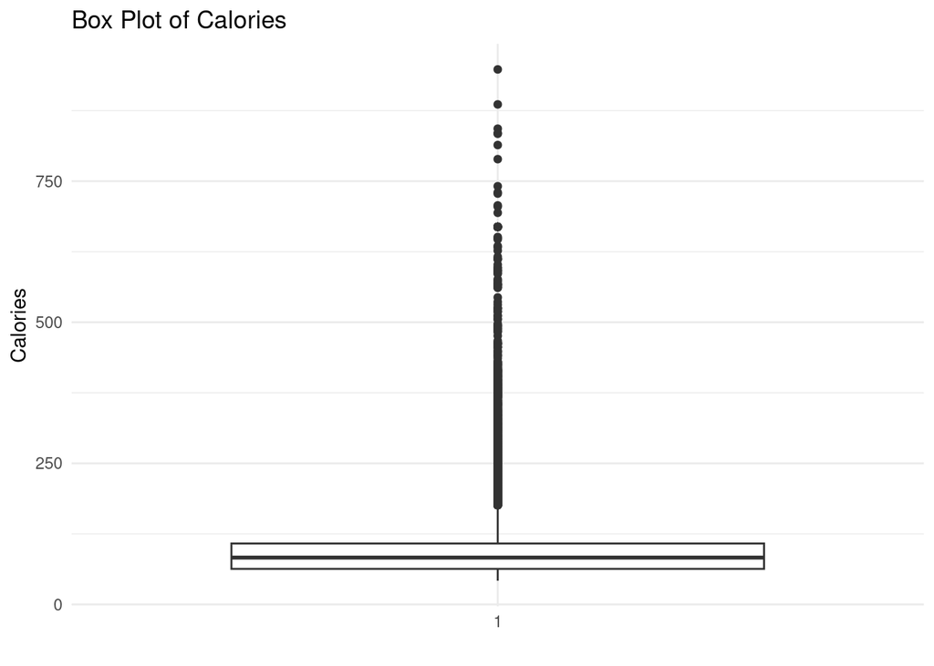

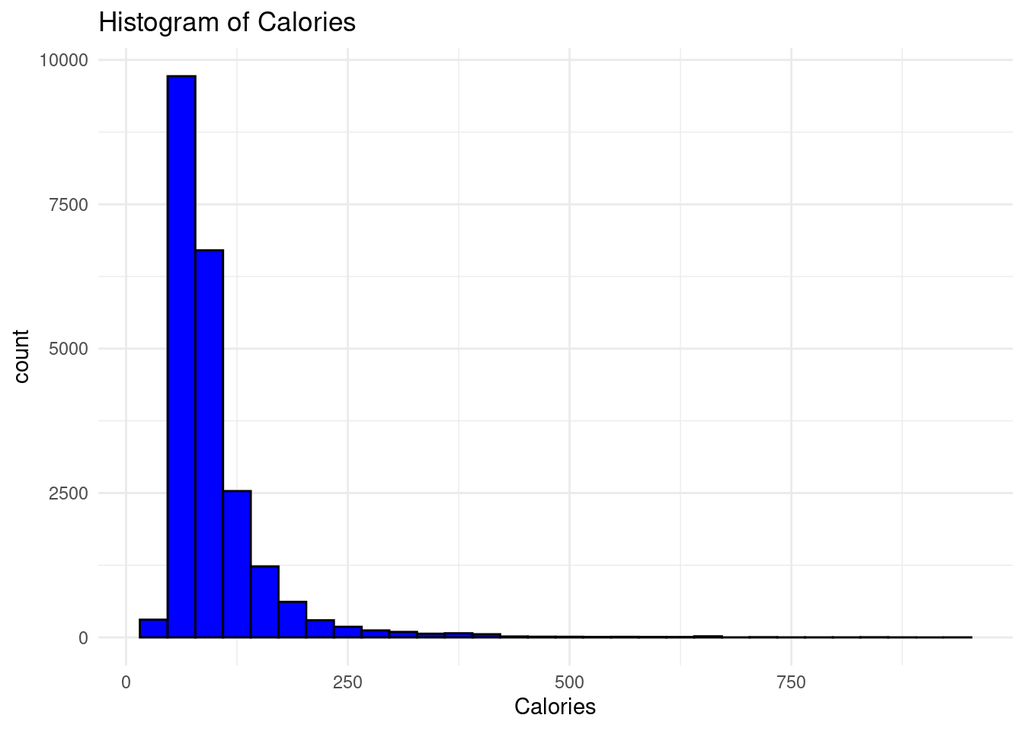

```r
# Running the histbox on hourly_data columns
hist_box(hourly_data, "Calories")
```

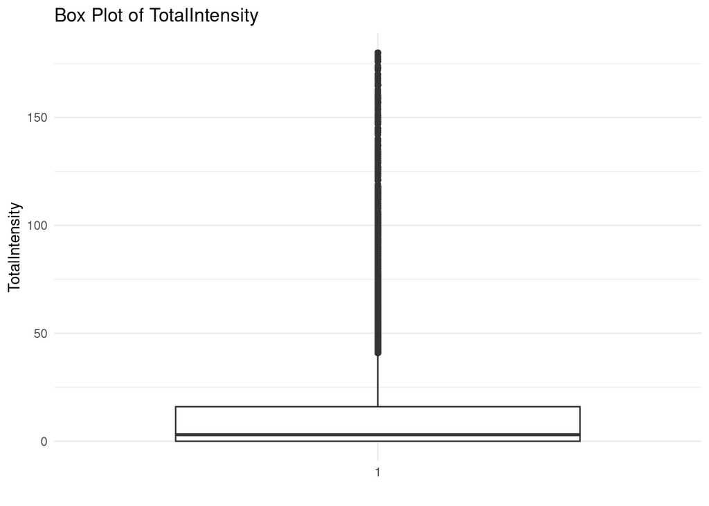

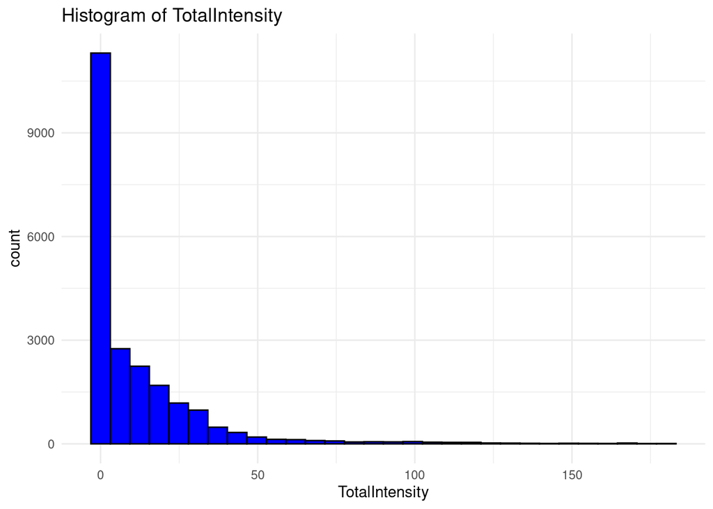

```r
hist_box(hourly_data, "TotalIntensity")
```

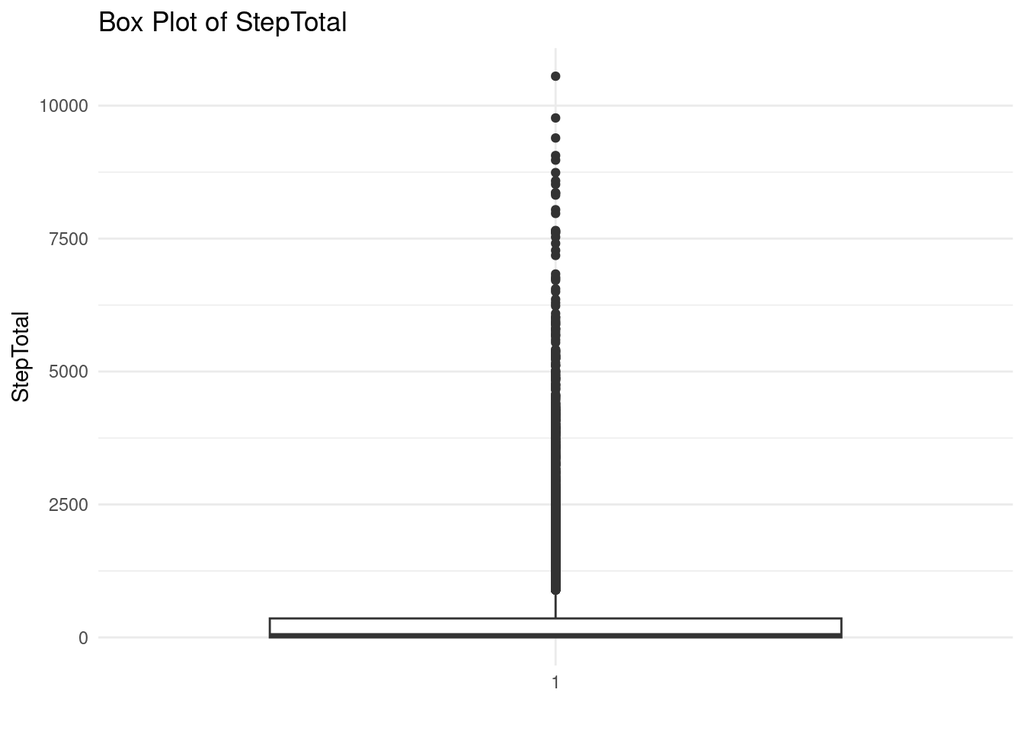

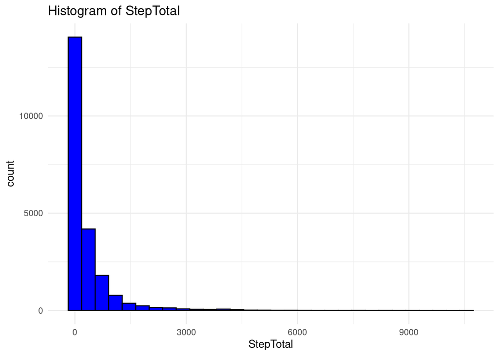

```r
hist_box(hourly_data, "StepTotal")
```

And now to proceed to the analysis of the data.

# Analysis

### Hourly Data (Steps, Intensity, Calories)

Let’s start with the hourly_data, examining how these data vary over the course of a day and over the course of a week. First, I’ll create an aggregate dataset of the means for the primary variables of interest (Intensity, StepTotal, Calories) grouped by Hour, and then visualize that.

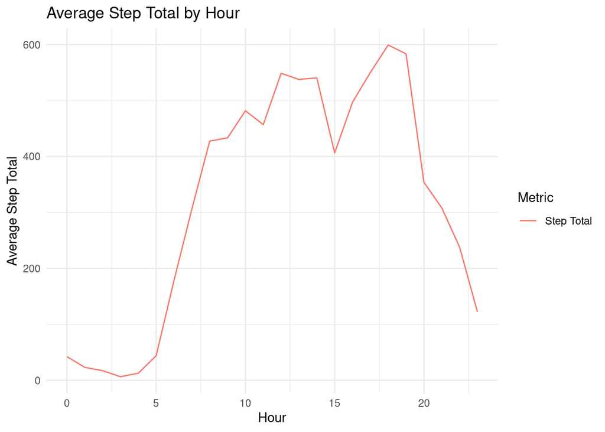

```r
library(dplyr)
hourly_agg <- hourly_data %>%
  group_by(Hour) %>%
  summarise(
    AvgStepTotal = mean(StepTotal, na.rm = TRUE),
    AvgTotalIntensity = mean(TotalIntensity, na.rm = TRUE),
    AvgCalories = mean(Calories, na.rm = TRUE)
  )

# Since the scale of StepTotal is different from TotalIntensity and Calories, I'll plot StepTotal by itself.
library(ggplot2)
# Plot for StepTotal
ggplot(hourly_agg, aes(x = Hour)) +
  geom_line(aes(y = AvgStepTotal, color = "Step Total")) +
  labs(y = "Average Step Total", color = "Metric") +
  theme_minimal() +
  ggtitle("Average Step Total by Hour")
```

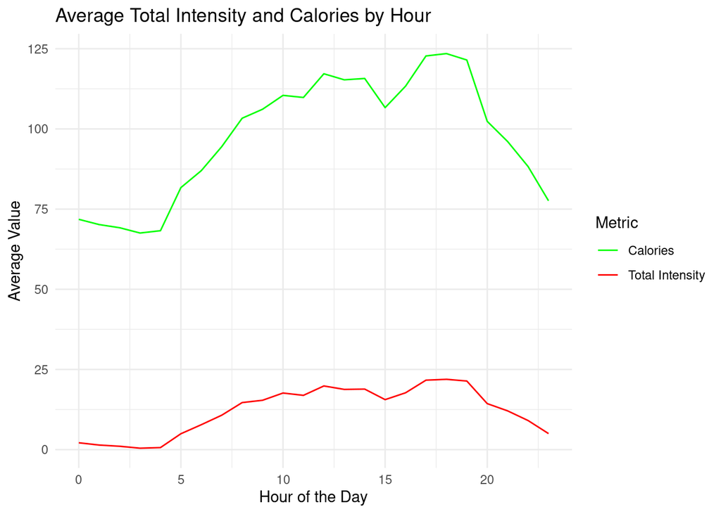

```r
# Plot for TotalIntensity and Calories on the same plot
ggplot(hourly_agg) +
  geom_line(aes(x = Hour, y = AvgTotalIntensity, color = "Total Intensity")) +
  geom_line(aes(x = Hour, y = AvgCalories, color = "Calories")) +
  scale_color_manual(values = c("Total Intensity" = "red", "Calories" = "green")) +
  labs(y = "Average Value", x = "Hour of the Day", color = "Metric") +
  theme_minimal() +
  ggtitle("Average Total Intensity and Calories by Hour")
```

We can see a clear trendline here in terms of which hours of the day the users (in aggregate) are recording the most steps, calories burned, and intensity, though we do see greater variation hourly in terms of steps. We see a very low amount of activity and steps from roughly 10pm to 5am, corresponding to the most common hours for sleep, though the fact that we still see some calories burned indicates that users are wearing their Fitbit and that we have a baseline metabolism of around 70 calories burned per hour during sleep.

Activity increases sharply from 5am to 8am, and then varies up and down from 8am to 8pm, where it drops sharply. During the main hours of the day, we see a clear bimodal distribution, with the highest peak at around 6pm-7pm (likely corresponding to people exercising or doing other activities after work), a lower peak between 12pm and 2pm (perhaps corresponding to exercise or other activity during a lunch break from work), and a significant trough between those two peaks right around 3pm, which from personal experience corresponds with my lowest energy time of day.

All three graphs corroborate this, though the variation is clearest in the StepTotal chart.

Given that these graphs are aggregated across all days of the week (and my conclusions are mostly surmising about how this interacts with the work day), let’s see how much variation there is between weekdays and weekends, focusing on StepTotal as the variable.

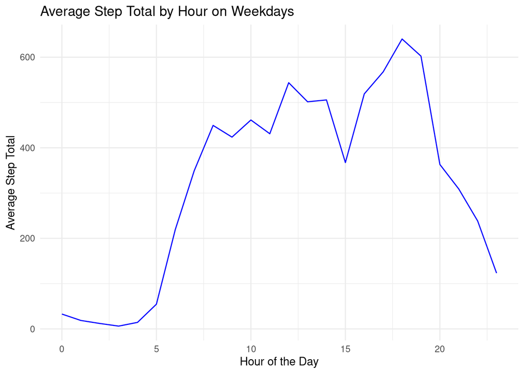

```r
library(dplyr)
library(ggplot2)

# This is to plot hourly step variation between weekdays and weekends

# Create a new column to distinguish between Weekday and Weekend
hourly_data <- hourly_data %>%
  mutate(DayType = case_when(
    WeekDay %in% c('Saturday', 'Sunday') ~ 'Weekend',
    TRUE ~ 'Weekday'
  ))

# Recalculate AvgStepTotal with the new grouping
hourly_agg_daytype <- hourly_data %>%
  group_by(Hour, DayType) %>%
  summarise(AvgStepTotal = mean(StepTotal, na.rm = TRUE)) %>%
  ungroup()
# Plot for Weekdays
ggplot(hourly_agg_daytype %>% filter(DayType == 'Weekday'), aes(x = Hour, y = AvgStepTotal)) +
  geom_line(color = "blue") +
  labs(y = "Average Step Total", x = "Hour of the Day") +
  theme_minimal() +
  ggtitle("Average Step Total by Hour on Weekdays")
```

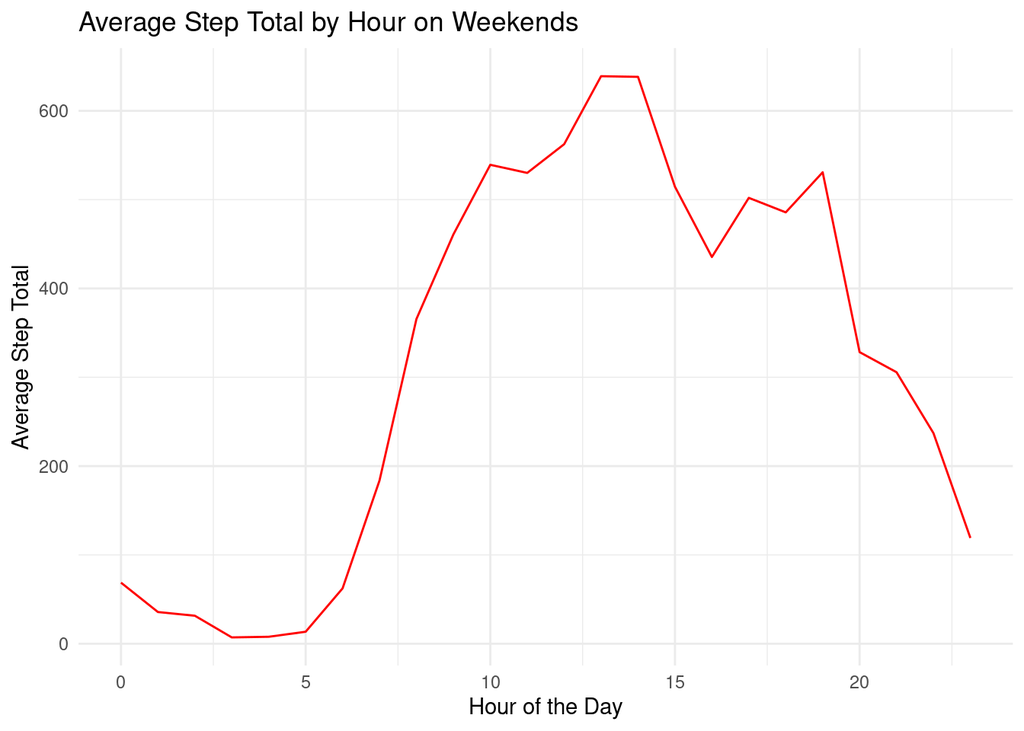

```r
# Plot for Weekends
ggplot(hourly_agg_daytype %>% filter(DayType == 'Weekend'), aes(x = Hour, y = AvgStepTotal)) +
  geom_line(color = "red") +
  labs(y = "Average Step Total", x = "Hour of the Day") +
  theme_minimal() +
  ggtitle("Average Step Total by Hour on Weekends")
```

Our graph of the step total during the weekdays looks very similar to our previous conclusions, suggesting that a lot of the variation is based on the workday (and being suggestive of the idea that most users work a standard week). During the weekdays, we see the most activity (in terms of steps taken) happening between 6-7pm (soon after work), with a smaller peak between 12pm-2pm (during lunchtime). On the weekends, we get a somewhat different spread. The variations around sleep are very similar (with activity dropping sharply around 8pm), but the peak activity time is between 1-2pm, with a trough around 4pm (instead of 3pm like during the weekdays), and another smaller peak around 7pm.  
These data suggest that the most popular times for activity (in terms of steps registered on the Fitbit) are midday (12pm-2pm) and in the evening (around 7pm), and a trough in the middle (between 3-4pm) though the size of the peaks switches on the weekends compared to the weekdays.

Let’s examine overall how much variation in activity we get over the days of the week, in aggregate.

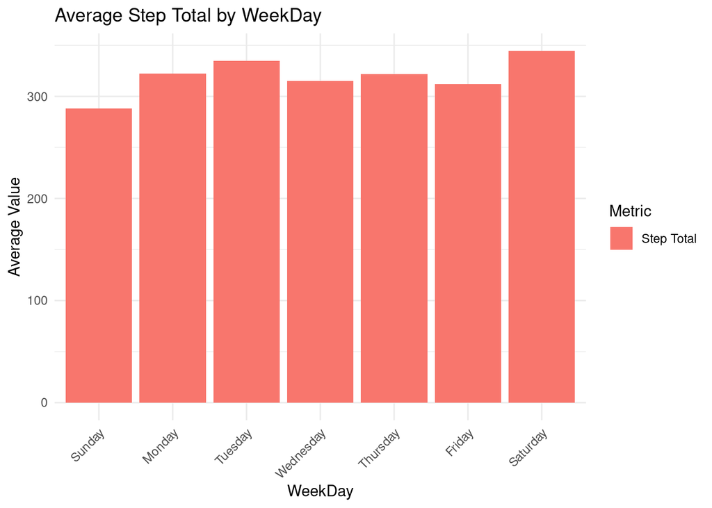

```r
# Visualizing trends by day of the week in hourly data

daily_agg <- hourly_data %>%
  group_by(WeekDay) %>%
  summarise(
    AvgStepTotal = mean(StepTotal, na.rm = TRUE),
    AvgTotalIntensity = mean(TotalIntensity, na.rm = TRUE),
    AvgCalories = mean(Calories, na.rm = TRUE)
  )

#I'll create separate plots for each one, since they are on different scales

ggplot(daily_agg, aes(x = WeekDay)) +
  geom_bar(aes(y = AvgStepTotal, fill = "Step Total"), stat = "identity", position = "dodge") +
  labs(y = "Average Value", fill = "Metric") +
  theme_minimal() +
  theme(axis.text.x = element_text(angle = 45, hjust = 1)) +
  ggtitle("Average Step Total by WeekDay")
```

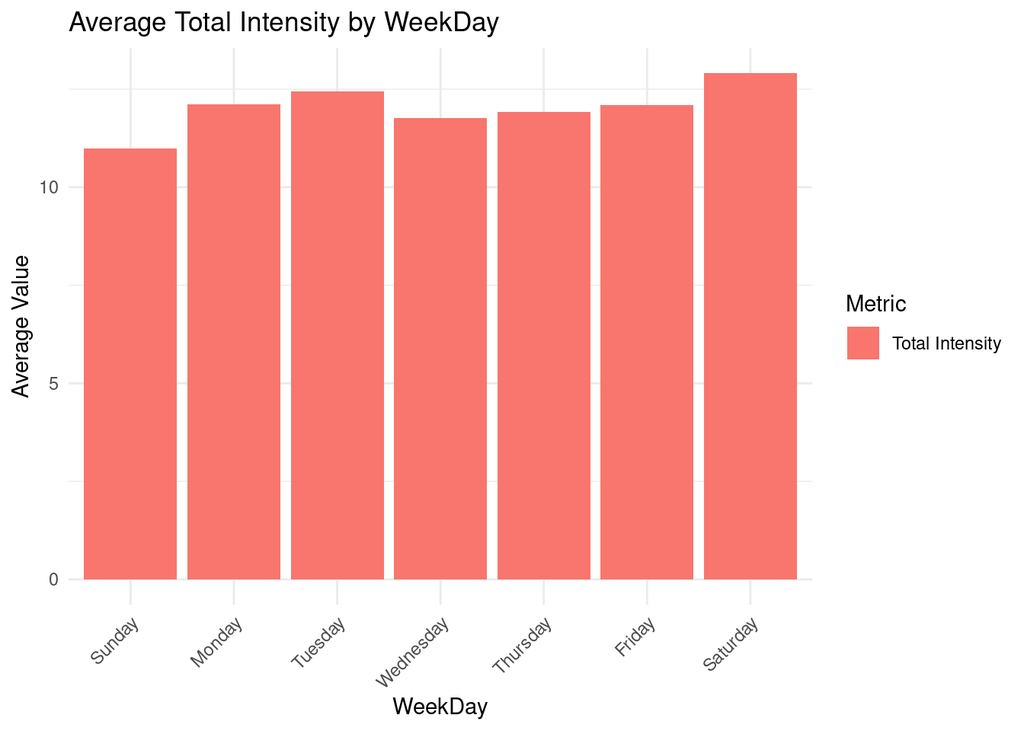

```r
ggplot(daily_agg, aes(x = WeekDay)) +
  geom_bar(aes(y = AvgTotalIntensity, fill = "Total Intensity"), stat = "identity", position = "dodge") +
  labs(y = "Average Value", fill = "Metric") +
  theme_minimal() +
  theme(axis.text.x = element_text(angle = 45, hjust = 1)) +
  ggtitle("Average Total Intensity by WeekDay")
```

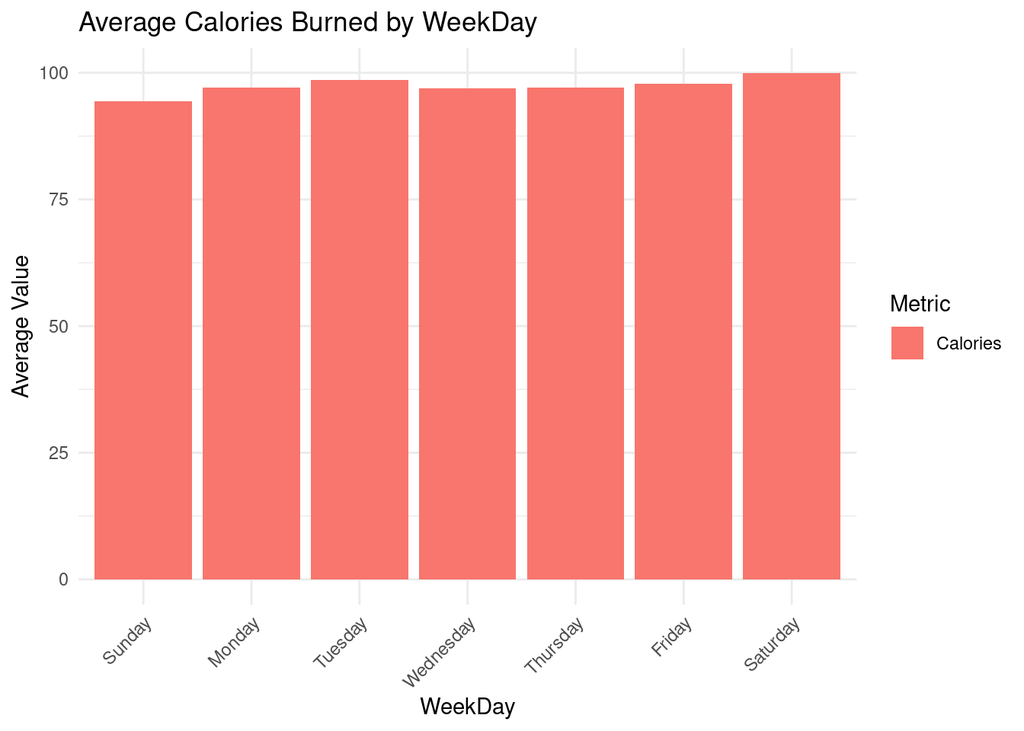

```r
ggplot(daily_agg, aes(x = WeekDay)) +
    geom_bar(aes(y = AvgCalories, fill = "Calories"), stat = "identity", position = "dodge") +
  labs(y = "Average Value", fill = "Metric") +
  theme_minimal() +
  theme(axis.text.x = element_text(angle = 45, hjust = 1)) +
  ggtitle("Average Calories Burned by WeekDay")
```

Interestingly, Calories shows little variation (though the variation it does have matches the other variables), which corresponds with the idea that most of the calories that we burn is from our basic metabolism and that exercise doesn’t have an exceptional effect.

Looking at Intensity and Steps, we see nearly identical graphs (with the exception of Thursday and Friday: here we see more steps on Thursday and fewer on Friday, while we see a higher average intensity on Friday. This may correspond to different types of activity on the two days [for example, more intense activity on Friday that doesn’t require as many steps, like swimming], but there is not enough variation to be sure). Otherwise, we a clear trend with Saturday being the most active day of the week (in terms of Avg Steps and Avg Total Intensity), followed by Tuesday and then Monday, with Sunday clearly being the least active day of the week.

Summarizing the Hourly Data overall, we can make the following conclusions:

- The most active days among the users in this dataset (on average) are Saturdays, Tuesdays, and Mondays.
- Sundays are the least active days.
- On weekdays, the most active times are around 6pm-7pm, with a smaller peak from 12pm-2pm, and a significant trough around 3pm.
- On weekends, the most active times are around 12pm-2pm, with a smaller peak around 7pm, and a significant trough around 4pm.
- There is not much variation in calories burned day to day, despite variations in activity

### Daily Activity

Let’s explore the daily_activity dataset in more detail now. Let’s remind ourselves of the variables we’re looking and some of the summary data.

```r
summary(daily_activity)
```

```
##        Id                 Date              TotalSteps    TotalDistance
##  Min.   :1.504e+09   Min.   :2016-04-12   Min.   :    0   Min.   : 0.000
##  1st Qu.:2.320e+09   1st Qu.:2016-04-19   1st Qu.: 3790   1st Qu.: 2.620
##  Median :4.445e+09   Median :2016-04-26   Median : 7406   Median : 5.245
##  Mean   :4.855e+09   Mean   :2016-04-26   Mean   : 7638   Mean   : 5.490
##  3rd Qu.:6.962e+09   3rd Qu.:2016-05-04   3rd Qu.:10727   3rd Qu.: 7.713
##  Max.   :8.878e+09   Max.   :2016-05-12   Max.   :36019   Max.   :28.030
##
##  VeryActiveDistance ModeratelyActiveDistance LightActiveDistance
##  Min.   : 0.000     Min.   :0.0000           Min.   : 0.000
##  1st Qu.: 0.000     1st Qu.:0.0000           1st Qu.: 1.945
##  Median : 0.210     Median :0.2400           Median : 3.365
##  Mean   : 1.503     Mean   :0.5675           Mean   : 3.341
##  3rd Qu.: 2.053     3rd Qu.:0.8000           3rd Qu.: 4.782
##  Max.   :21.920     Max.   :6.4800           Max.   :10.710
##
##  VeryActiveMinutes FairlyActiveMinutes LightlyActiveMinutes SedentaryMinutes
##  Min.   :  0.00    Min.   :  0.00      Min.   :  0.0        Min.   :   0.0
##  1st Qu.:  0.00    1st Qu.:  0.00      1st Qu.:127.0        1st Qu.: 729.8
##  Median :  4.00    Median :  6.00      Median :199.0        Median :1057.5
##  Mean   : 21.16    Mean   : 13.56      Mean   :192.8        Mean   : 991.2
##  3rd Qu.: 32.00    3rd Qu.: 19.00      3rd Qu.:264.0        3rd Qu.:1229.5
##  Max.   :210.00    Max.   :143.00      Max.   :518.0        Max.   :1440.0
##
##     Calories         WeekDay
##  Min.   :   0   Sunday   :121
##  1st Qu.:1828   Monday   :120
##  Median :2134   Tuesday  :152
##  Mean   :2304   Wednesday:150
##  3rd Qu.:2793   Thursday :147
##  Max.   :4900   Friday   :126
##                 Saturday :124
```

```r
head(daily_activity)
```

```
##           Id       Date TotalSteps TotalDistance VeryActiveDistance
## 1 1503960366 2016-04-12      13162          8.50               1.88
## 2 1503960366 2016-04-13      10735          6.97               1.57
## 3 1503960366 2016-04-14      10460          6.74               2.44
## 4 1503960366 2016-04-15       9762          6.28               2.14
## 5 1503960366 2016-04-16      12669          8.16               2.71
## 6 1503960366 2016-04-17       9705          6.48               3.19
##   ModeratelyActiveDistance LightActiveDistance VeryActiveMinutes
## 1                     0.55                6.06                25
## 2                     0.69                4.71                21
## 3                     0.40                3.91                30
## 4                     1.26                2.83                29
## 5                     0.41                5.04                36
## 6                     0.78                2.51                38
##   FairlyActiveMinutes LightlyActiveMinutes SedentaryMinutes Calories   WeekDay
## 1                  13                  328              728     1985   Tuesday
## 2                  19                  217              776     1797 Wednesday
## 3                  11                  181             1218     1776  Thursday
## 4                  34                  209              726     1745    Friday
## 5                  10                  221              773     1863  Saturday
## 6                  20                  164              539     1728    Sunday
```

Here we have daily data showing total steps, total distance, calories, weekday, and measures of both minutes and distance traveled in a variety of different activity categories (presumably based on heart-rate, though that isn’t mentioned in the metadata), with the activity categories being: Sedentary, Lightly Active, Fairly Active, Moderately Active, and Very Active. Note: There is “ModeratelyActiveDistance” and “FairlyActiveMinutes”, which I presume to be alluding to the same thing.

Let’s start by running all these variables through my previously defined histbox function to visualize distributions.

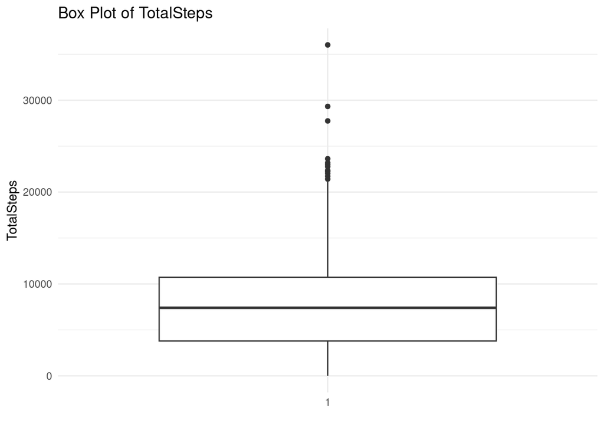

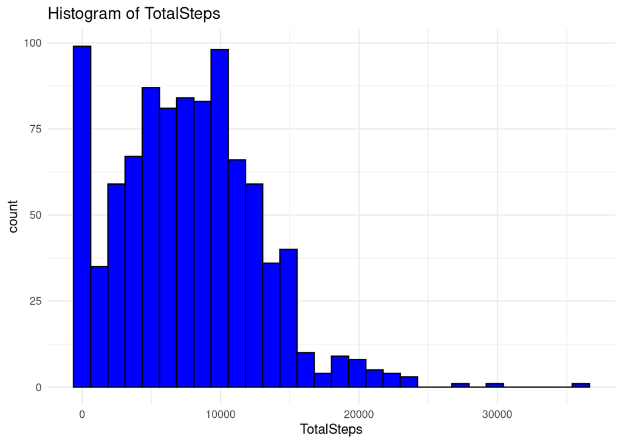

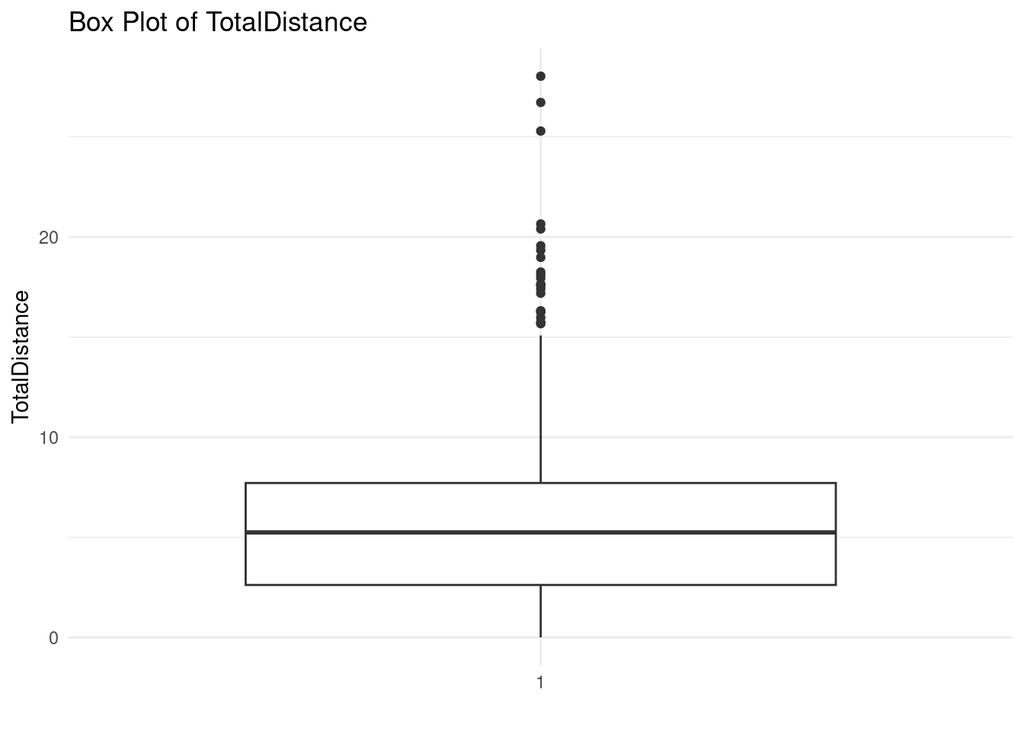

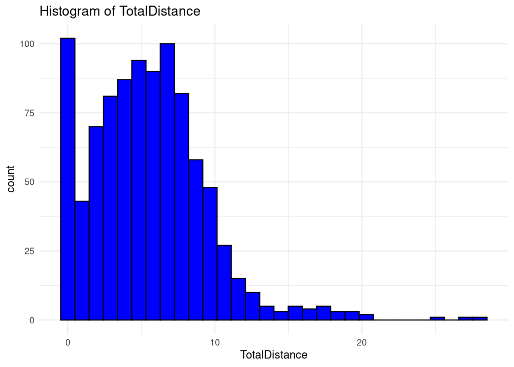

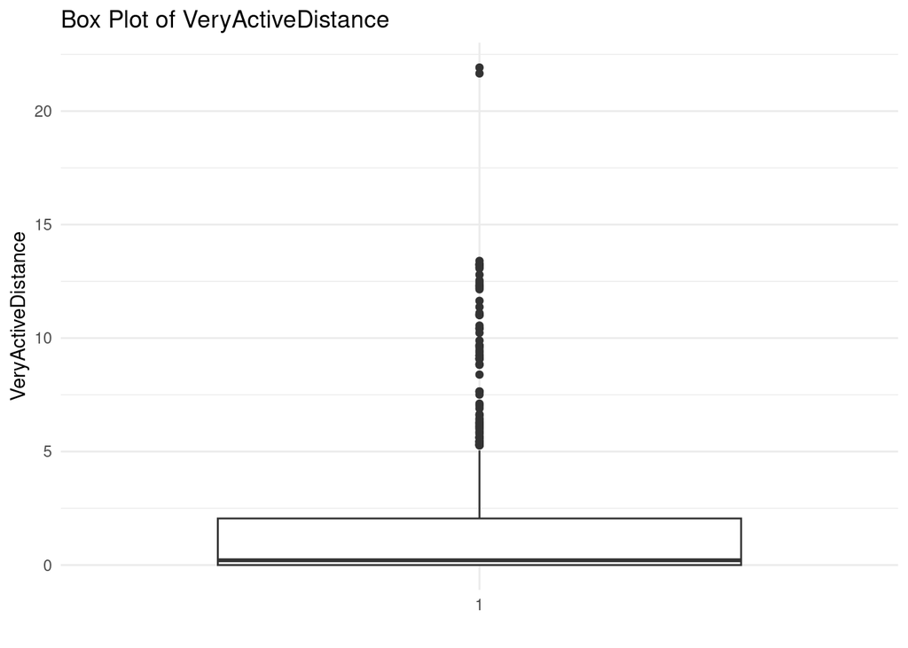

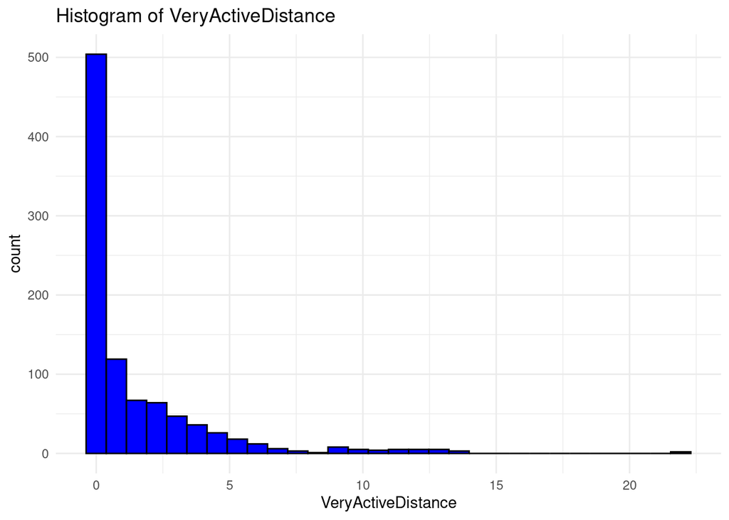

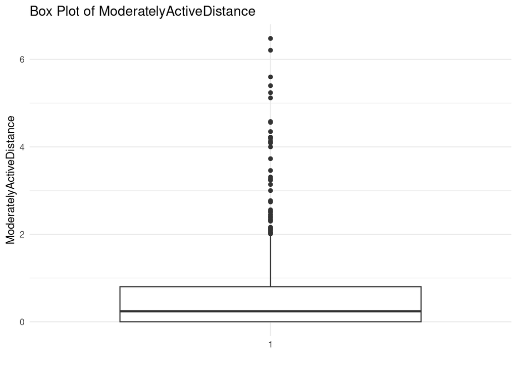

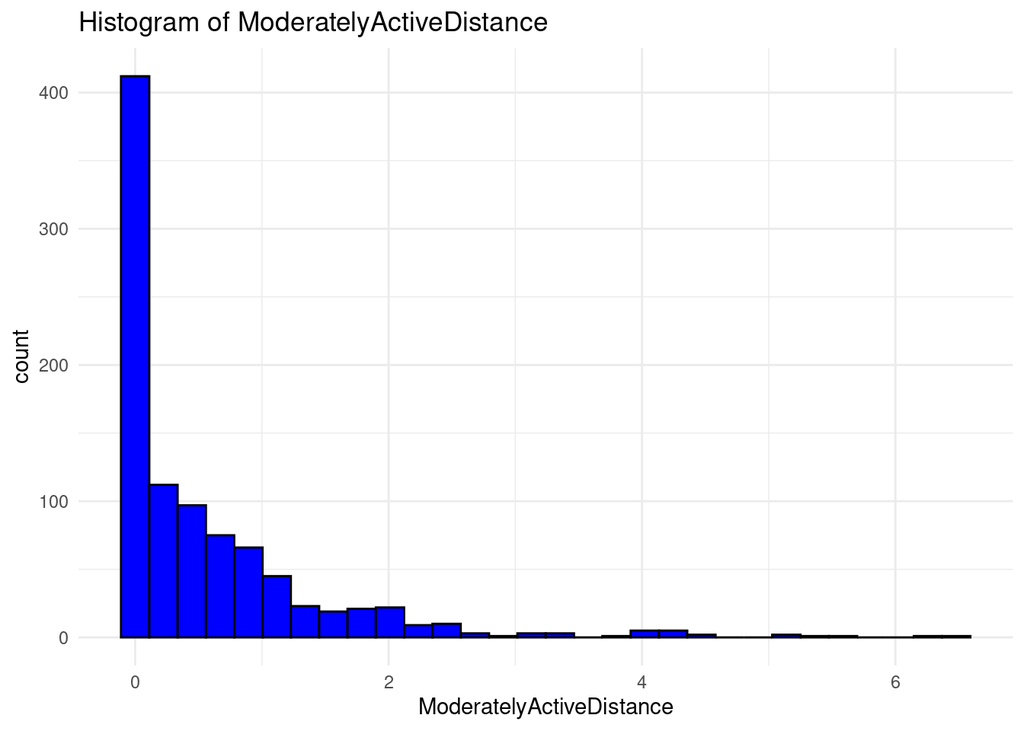

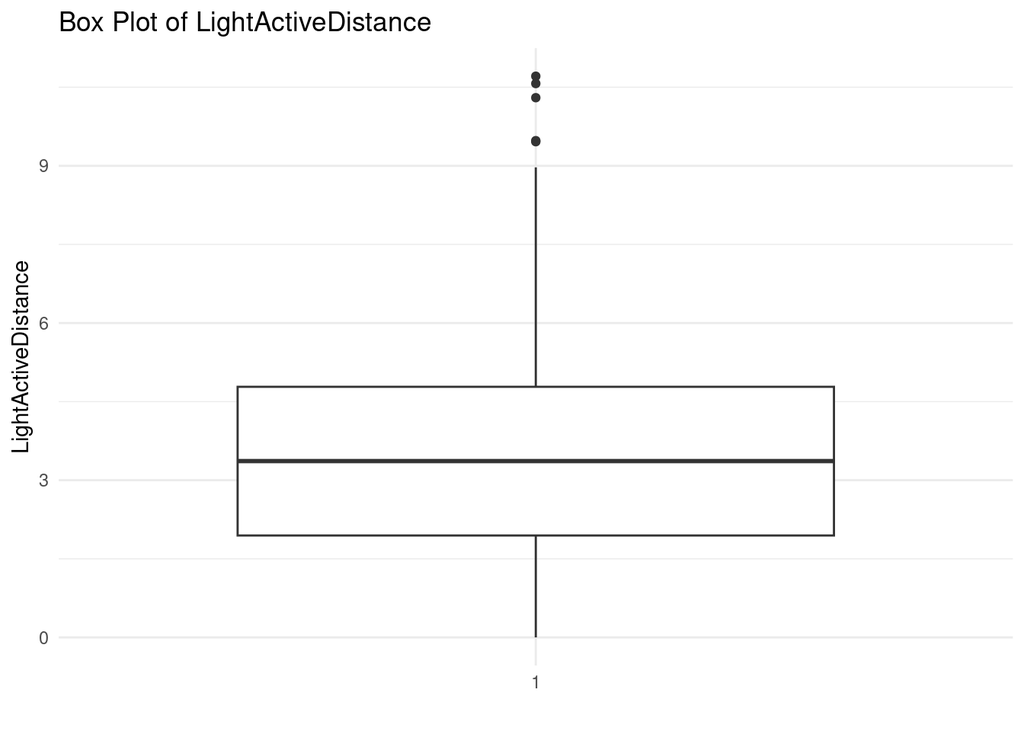

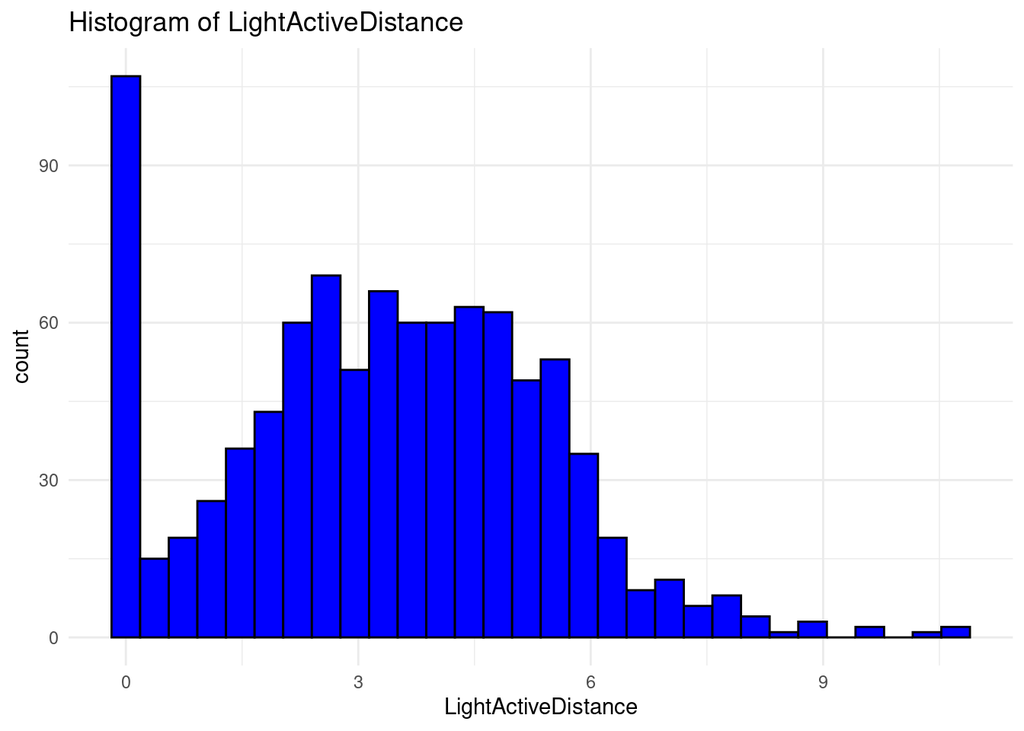

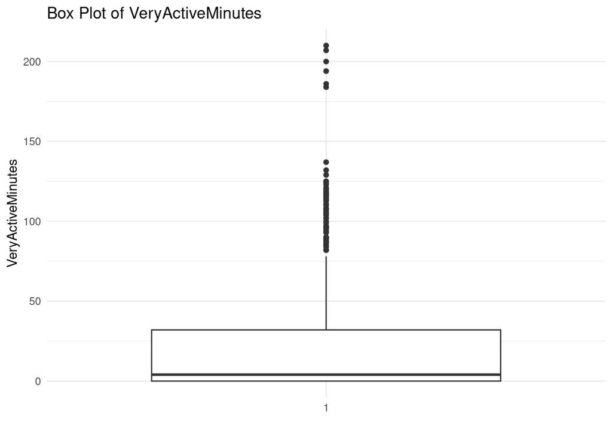

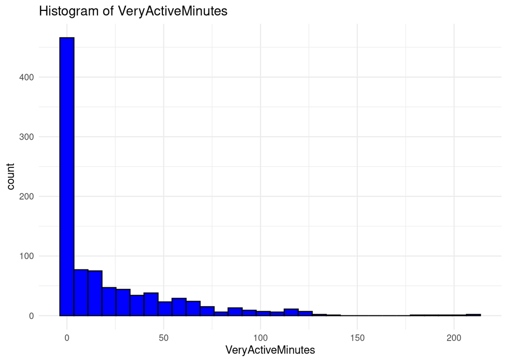

[8 more figures not shown]

```r
variables_to_plot <- c("TotalSteps", "TotalDistance", "VeryActiveDistance",
                       "ModeratelyActiveDistance", "LightActiveDistance",
                       "VeryActiveMinutes", "FairlyActiveMinutes",
                       "LightlyActiveMinutes", "SedentaryMinutes", "Calories")

for(var in variables_to_plot) {
  hist_box(daily_activity, var)
}
```

*Activity Levels:*

The range in TotalSteps and TotalDistance suggests a wide variation in daily activity levels among participants, with some being very inactive (min of 0 steps and 0 distance) and others being highly active (max of 36,019 steps and 28.03 km). The mean values being slightly higher than the median for both TotalSteps and TotalDistance indicate a right-skewed distribution, suggesting that a smaller number of very active individuals push the average up.

*Intensity of Activity:*

The minimum values for VeryActiveDistance, ModeratelyActiveDistance, LightActiveDistance, and VeryActiveMinutes are 0, indicating that there are days when participants do not engage in any significant physical activity. The maximum values, especially for VeryActiveMinutes (210 minutes) and VeryActiveDistance (21.92 km), indicate that some participants engage in extensive high-intensity activities. The averages for these variables suggest that most activity is light, with LightActiveDistance having a higher mean than VeryActiveDistance and ModeratelyActiveDistance.

*Sedentary Behavior:*

The wide range in SedentaryMinutes (from 0 to 1440 minutes, which is a full day) highlights varying levels of sedentary behavior among participants. The mean SedentaryMinutes is less than the median, suggesting a left-skewed distribution where most participants have higher sedentary minutes, but a significant number of very active participants lower the average.

*Caloric Burn:*

Calories burned ranges widely from 0 to 4900, indicating significant differences in daily energy expenditure among participants. This variance is likely influenced by the varying levels of physical activity and possibly by differences in metabolic rates or inaccuracies in calorie estimation algorithms.

*Temporal Patterns:*

The distribution of WeekDay entries suggests that the dataset is fairly balanced across different days of the week, with a slight increase in data points for Tuesday and Wednesday. This balance allows for analyzing daily patterns without bias toward specific days.

*Other observations:*

Across activity levels and distances (except Sedentary), the most common entry is 0 and the distribution is highly right-skewed, with significant outliers in most of the variables. The most common entry in Sedentary Minutes is 1440, which is an entire day, and it’s mostly left-skewed. Interestingly, there are a number of entries that show 400 or fewer minutes of Sedentary activity (including 0), which seems unlikely given that most people, I assume, are sedentary during sleep. Couple this with the large number of entries showing 0 steps and 0 calories burned (and comparing this to our hourly data which showed a significant mean calorie burn even during sleeping hours), this suggests that either people weren’t wearing their FitBits or they weren’t functioning properly. I’m assuming that registering 0 minutes for Very Active and Moderately Active minutes is not surprising, but that 0 calories, 0 steps, or 1440 minutes of sedentary activity are unexpected given that people are actively wearing their FitBits and they are working properly. Let’s remove some of these outliers and examine the histograms given that.

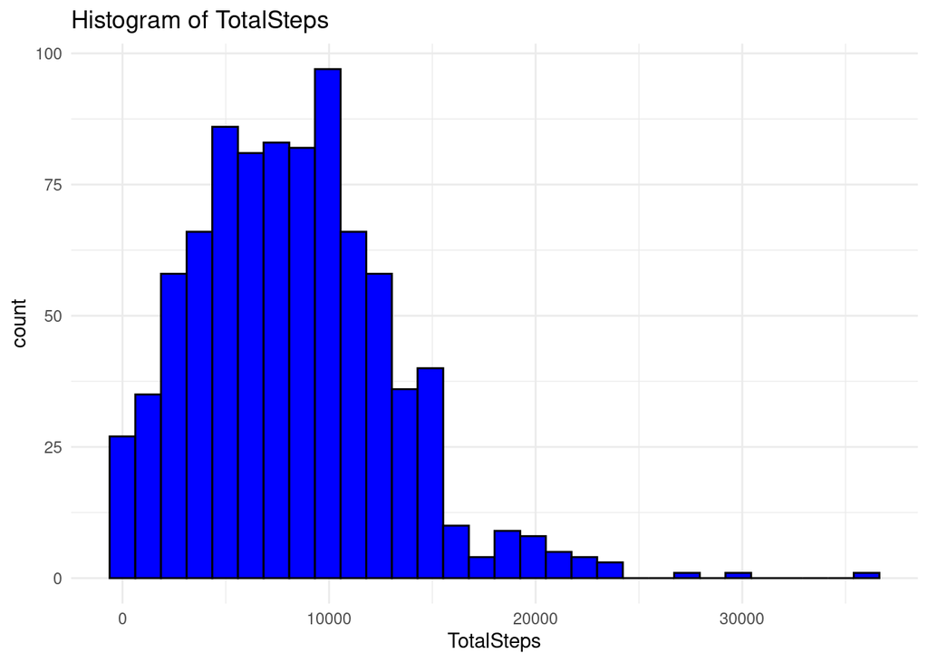

```r
library(dplyr)
library(ggplot2)

# Step 1: Filter out unlikely data points
cleaned_daily_activity <- daily_activity %>%
  filter(!(TotalSteps == 0 & Calories == 0)) %>%
  filter(SedentaryMinutes < 1440)

# Step 2: Re-examine distributions with histograms for key variables
# Defining a function to create a histogram for a given column
plot_histogram <- function(dataframe, column_name) {
  ggplot(dataframe, aes_string(x = column_name)) +
    geom_histogram(bins = 30, fill = "blue", color = "black") +
    theme_minimal() +
    ggtitle(paste("Histogram of", column_name))
}
# Let's focus on minutes rather than distance for now (though we'll keep TotalDistance)

# Applying the function to key variables
plot_histogram(cleaned_daily_activity, "TotalSteps")
```

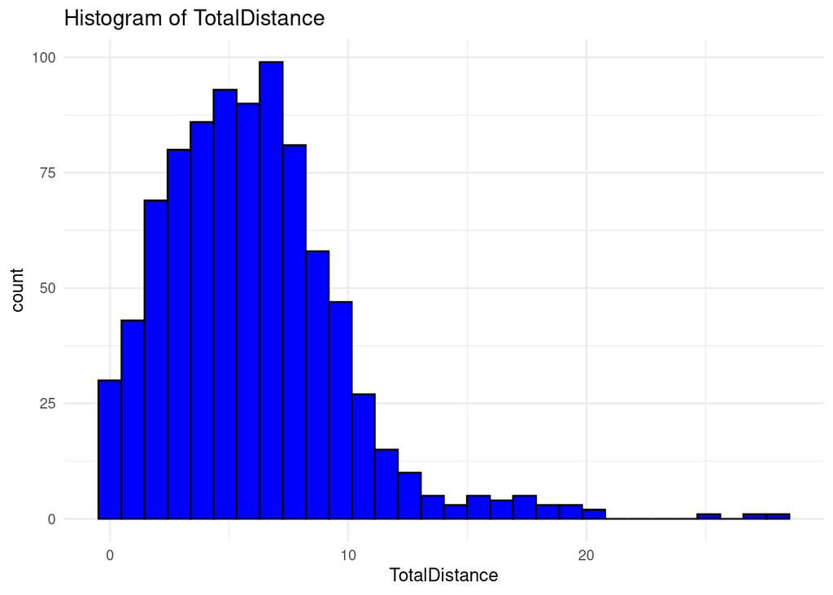

```r
plot_histogram(cleaned_daily_activity, "TotalDistance")
```

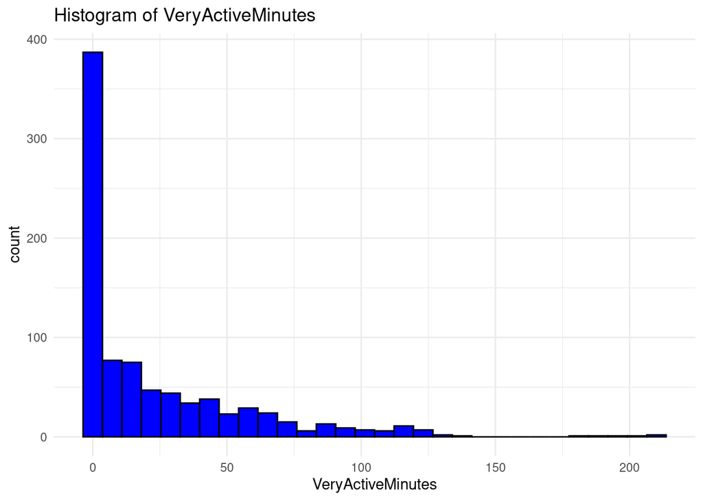

```r
plot_histogram(cleaned_daily_activity, "VeryActiveMinutes")
```

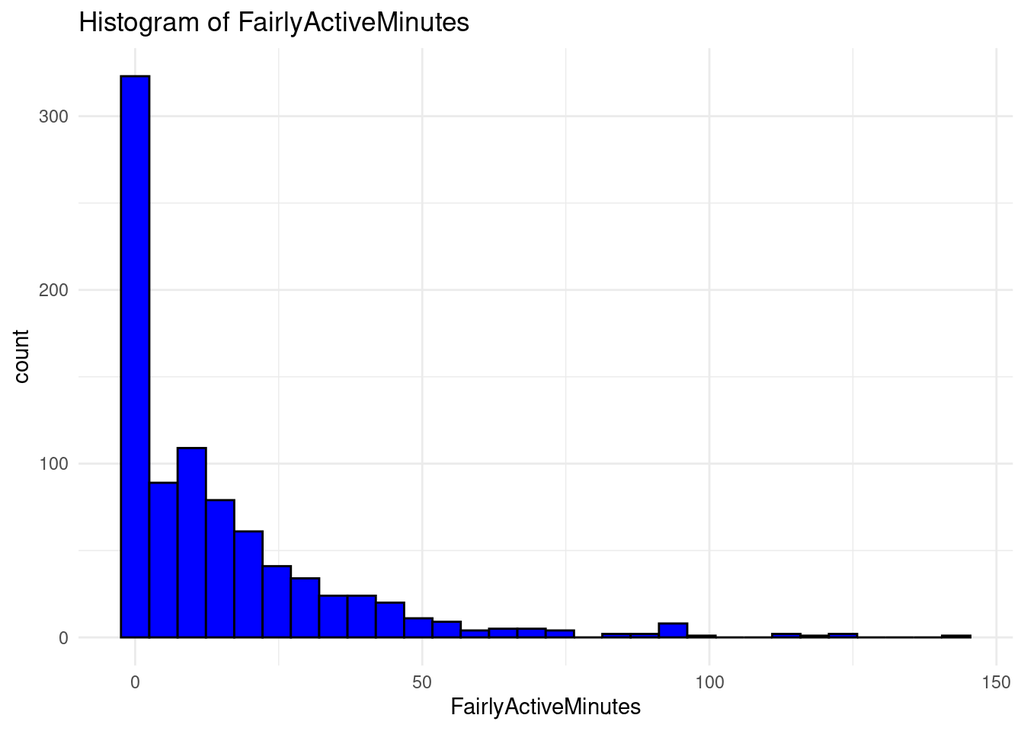

```r
plot_histogram(cleaned_daily_activity, "FairlyActiveMinutes")
```

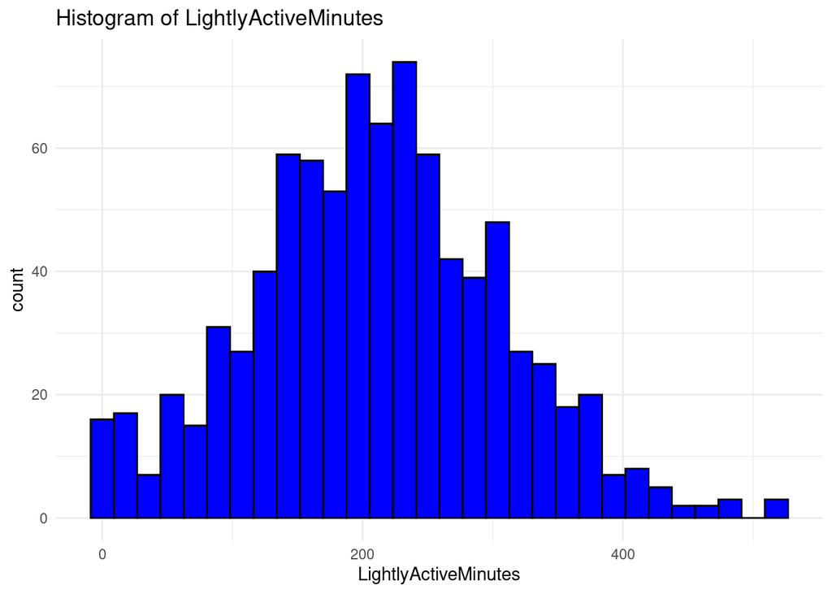

```r
plot_histogram(cleaned_daily_activity, "LightlyActiveMinutes")
```

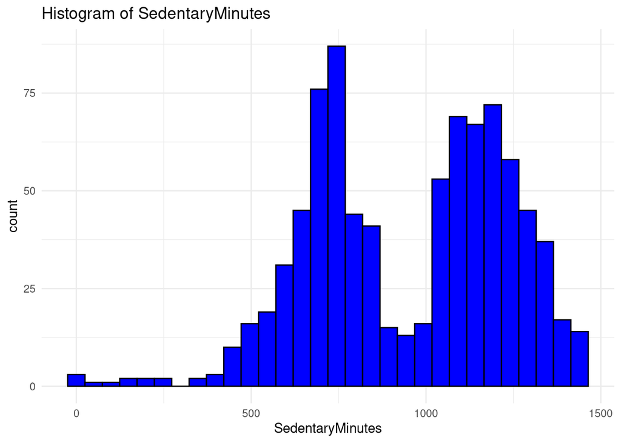

```r
plot_histogram(cleaned_daily_activity, "SedentaryMinutes")
```

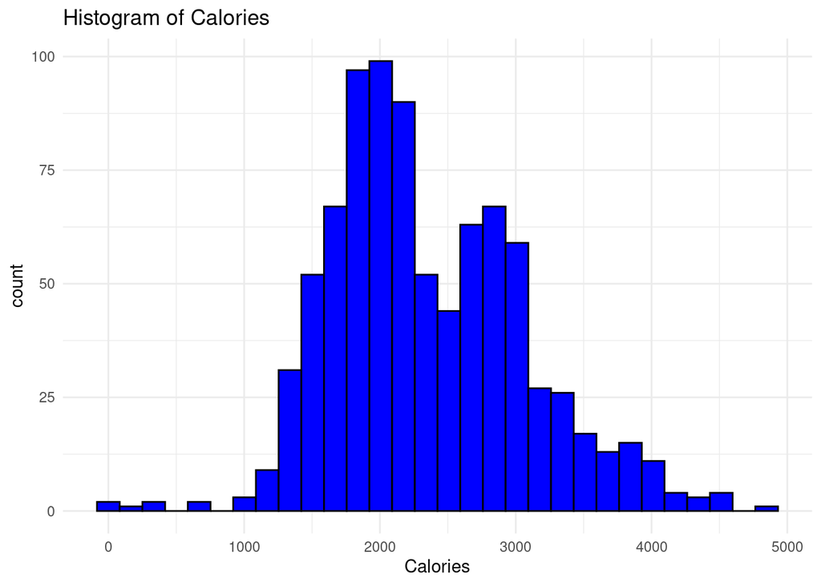

```r
plot_histogram(cleaned_daily_activity, "Calories")
```

**Distribution of Variables in cleaned_daily_activity**

These plots provide a perhaps more realistic view of peoples’ actual activity levels. We see quite a few entries with 0 “very active” or “fairly active” minutes, which is not surprising, but then “lightly active” minutes displays a close to normal distribution with a max around 500, which is very reasonable. Both “Total Steps” and “Total Distance” display a roughly normal though right-skewed distribution, with a small number of outliers to the right. The fact that they match is a good sign. Interestingly, both “Sedentary Minutes” and “Calories” show a somewhat similar bimodal distribution, with Sedentary Minutes showing peaks at ~750 and ~1200, with a significant trough between ~800-1000. “Calories” has a peak frequency of ~2000, a smaller peak at ~2800, and a trough around ~2500. The range of calories burned is mostly reasonable, though it looks to be pretty generous to their users with a significant percentage of the population showing 2500+ calories burned in a day, which happens but is not especially common for people registering so many sedentary minutes.

Let’s examine a few other explorations:

```r
library(ggplot2)
library(dplyr)

# Correlation between TotalSteps, TotalDistance, and Calories
correlation_matrix <- cleaned_daily_activity %>%
  select(TotalSteps, TotalDistance, Calories) %>%
  cor(use = "complete.obs")
print(correlation_matrix)
```

```
##               TotalSteps TotalDistance  Calories
## TotalSteps     1.0000000     0.9829121 0.5687550
## TotalDistance  0.9829121     1.0000000 0.6292285
## Calories       0.5687550     0.6292285 1.0000000
```

```r
# Average activity by user
avg_activity_by_user <- cleaned_daily_activity %>%
  group_by(Id) %>%
  summarise(
    AvgSteps = mean(TotalSteps, na.rm = TRUE),
    AvgActiveMinutes = mean(VeryActiveMinutes + FairlyActiveMinutes + LightlyActiveMinutes, na.rm = TRUE),
    AvgCalories = mean(Calories, na.rm = TRUE)
  )
print(avg_activity_by_user)
```

```
## # A tibble: 33 × 4
##            Id AvgSteps AvgActiveMinutes AvgCalories
##         <dbl>    <dbl>            <dbl>       <dbl>
##  1 1503960366   12521.            287.        1877.
##  2 1624580081    5744.            168.        1483.
##  3 1644430081    7283.            209.        2811.
##  4 1844505072    3636.            165.        1666.
##  5 1927972279    1578.             70.1       2252.
##  6 2022484408   11371.            313.        2510.
##  7 2026352035    5567.            257         1541.
##  8 2320127002    4717.            202.        1724.
##  9 2347167796    9520.            287.        2043.
## 10 2873212765    7556.            328.        1917.
## # ℹ 23 more rows
```

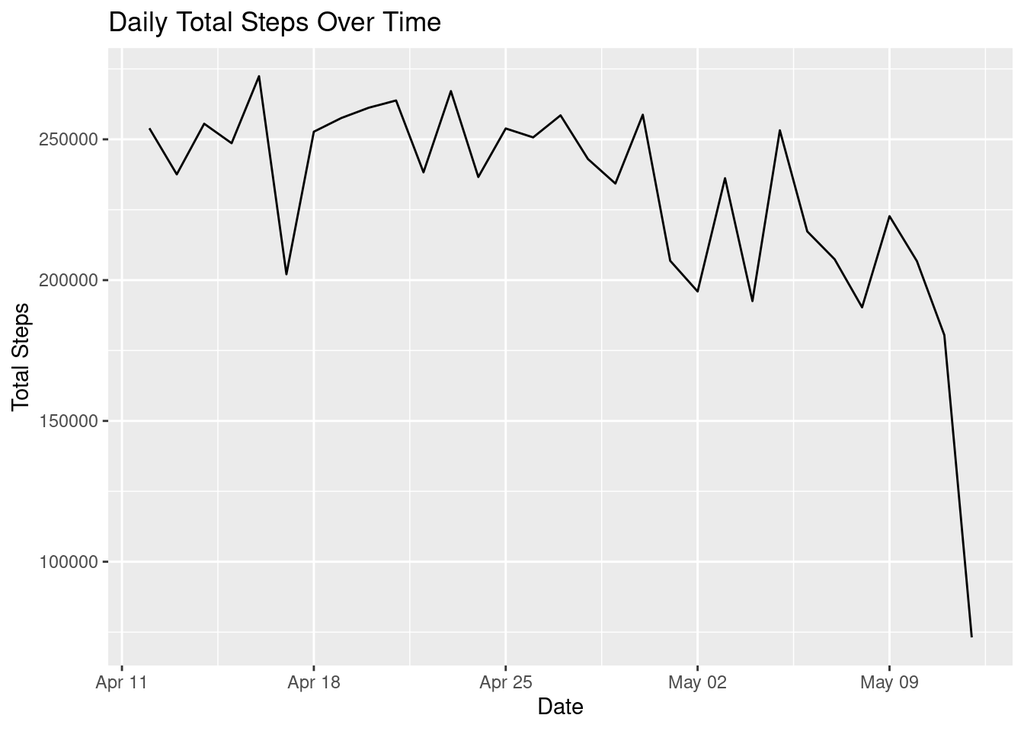

```r
# Time series of activity
cleaned_daily_activity %>%
  group_by(Date) %>%
  summarise(SumSteps = sum(TotalSteps)) %>%
  ggplot(aes(x = Date, y = SumSteps)) +
  geom_line() +
  labs(title = "Daily Total Steps Over Time", x = "Date", y = "Total Steps")
```

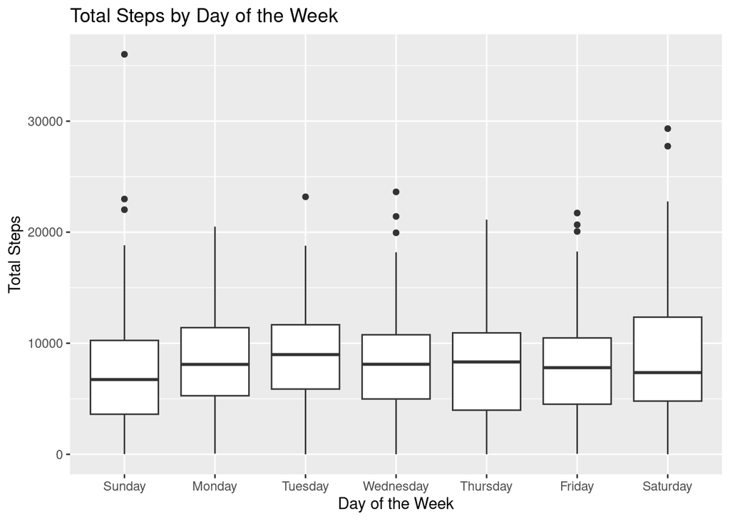

```r
# Boxplot of Total Steps by WeekDay
ggplot(cleaned_daily_activity, aes(x = WeekDay, y = TotalSteps)) +
  geom_boxplot() +
  labs(title = "Total Steps by Day of the Week", x = "Day of the Week", y = "Total Steps")
```

**Correlation**

When it comes to TotalSteps, TotalDistance, and Calories, we see an extremely strong correlation between steps and distance (not surprising), and only a moderate correlation between steps and calories and distance and calories, which is also not surprising given that most of our calorie expenditure is from our baseline metabolism and only affected somewhat by our activity.

**Steps over time**

Let’s examine the number of steps on different days of the period to see if the last couple days are an outlier that should be removed, and then we’ll see if we can identify clusters of user types.

```r
library(dplyr)

# Summarize total steps by date
steps_by_date <- cleaned_daily_activity %>%
  group_by(Date) %>%
  summarise(TotalStepsByDay = sum(TotalSteps, na.rm = TRUE)) %>%
  arrange(Date)  # Optional: Arrange by date for chronological order

# Display the summarized data
print(steps_by_date)
```

```
## # A tibble: 31 × 2
##    Date       TotalStepsByDay
##    <date>               <int>
##  1 2016-04-12          253941
##  2 2016-04-13          237558
##  3 2016-04-14          255538
##  4 2016-04-15          248617
##  5 2016-04-16          272414
##  6 2016-04-17          202088
##  7 2016-04-18          252703
##  8 2016-04-19          257557
##  9 2016-04-20          261215
## 10 2016-04-21          263795
## # ℹ 21 more rows
```

For whatever reason, there is a massive drop in the last day of the sample period down to a third of the long-run median. That was a Thursday and a Mother’s Day, so I’m not sure if that had any effect, or related at all to it being the last day of the period under observation. It’s a significant enough outlier to warrant removing it from the sample.

```r
cleaned_daily_activity <- cleaned_daily_activity %>%
  filter(Date != "2016-05-12")
```

**Identifying User Clusters**

Now let’s see if we can find user clusters based on aggregated data for each user. First, we’ll aggregate the data by user, scale it, and then use the elbow method to determine how many clusters I should look for.

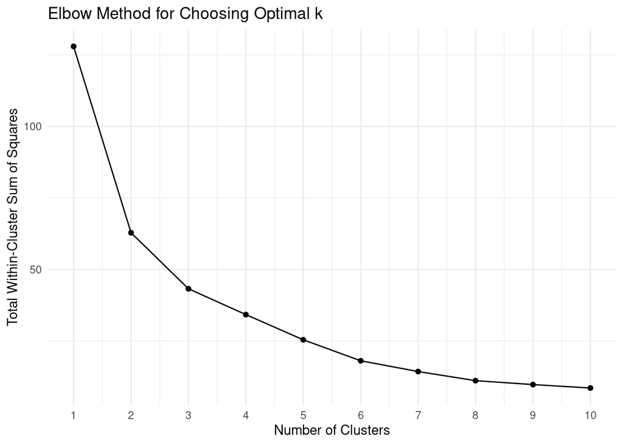

```r
library(dplyr)
library(cluster)
library(purrr)

# Aggregate data by user
user_activity_profile <- cleaned_daily_activity %>%
  group_by(Id) %>%
  summarise(
    AvgTotalSteps = mean(TotalSteps, na.rm = TRUE),
    AvgTotalDistance = mean(TotalDistance, na.rm = TRUE),
    AvgVeryActiveMinutes = mean(VeryActiveMinutes, na.rm = TRUE),
    AvgCalories = mean(Calories, na.rm = TRUE)
    # Add more features as needed
  )

# Scale the data
scaled_data <- scale(user_activity_profile[, -1])  # Excluding the Id column

# Calculate WSS for a range of number of clusters
set.seed(13)  # Ensure reproducibility
wss <- map_dbl(1:10, function(k) {
  kmeans(scaled_data, centers = k, nstart = 25)$tot.withinss
})

# Plot the elbow plot
elbow_plot <- tibble(Clusters = 1:10, WSS = wss) %>%
  ggplot(aes(x = Clusters, y = WSS)) +
  geom_line() + geom_point() +
  scale_x_continuous(breaks = 1:10) +
  labs(title = "Elbow Method for Choosing Optimal k",
       x = "Number of Clusters", y = "Total Within-Cluster Sum of Squares") +
  theme_minimal()

print(elbow_plot)
```

The elbow plot does not show a clear “elbow,” or point of inflection, suggesting that there isn’t an obvious cutoff where adding more clusters stops giving significantly better modeling of the data. This can happen for a few reasons:

Data Homogeneity: The data points might not be clearly segmented into distinct groups, possibly indicating that the dataset has a relatively uniform distribution without distinct subgroups.

Complex Cluster Shapes: K-means assumes that clusters are spherical and evenly sized, which might not be the case in the data. There could be clusters with non-spherical shapes or clusters that have very different sizes.

Overlapping Clusters: There may be some degree of overlap between the clusters, making it difficult to partition the data into well-separated groups.

High-Dimensional Space: If the data has many dimensions (features), the distance metrics used by K-means may become less meaningful (this is known as the “curse of dimensionality”), and the clusters may not be well-defined.

Let’s first see if we can get additional information through a Silhouette plot; after that, we could try hierarchical clustering, and then apply PCA.

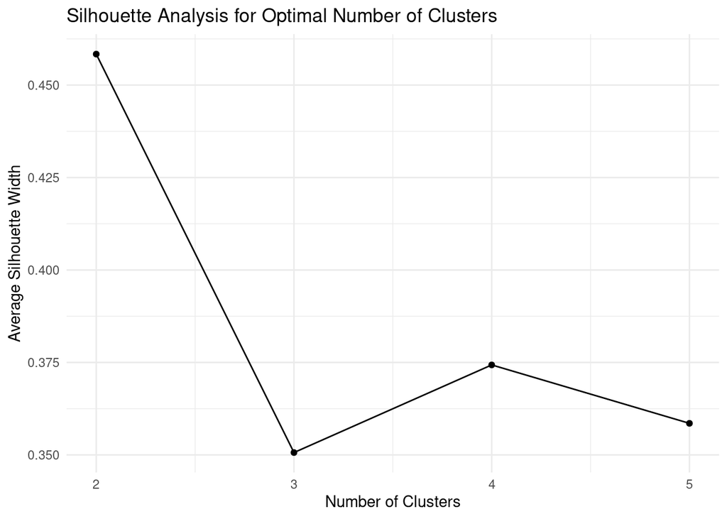

```r
library(cluster)
library(factoextra)  # For visualization of silhouette plots
# Compute silhouette scores for multiple values of k
sil_width <- list()
for (k in 2:5) {
  km <- kmeans(scaled_data, centers = k, nstart = 25)
  sil <- silhouette(km$cluster, dist(scaled_data))
  sil_width[[paste("k=", k, sep="")]] <- mean(sil[, "sil_width"])
}

# Plot silhouette scores for different numbers of clusters
sil_plot <- tibble(
  k = 2:5,
  silhouette_width = unlist(sil_width)
)

ggplot(sil_plot, aes(x = k, y = silhouette_width)) +
  geom_line() + geom_point() +
  labs(title = "Silhouette Analysis for Optimal Number of Clusters",
       x = "Number of Clusters",
       y = "Average Silhouette Width") +
  theme_minimal()
```

```r
# Print the silhouette plot
print(sil_plot)
```

```
## # A tibble: 4 × 2
##       k silhouette_width
##   <int>            <dbl>
## 1     2            0.458
## 2     3            0.351
## 3     4            0.374
## 4     5            0.359
```

```
##   cluster size ave.sil.width
## 1       1   13          0.28
## 2       2   16          0.43
## 3       3    4          0.26
```

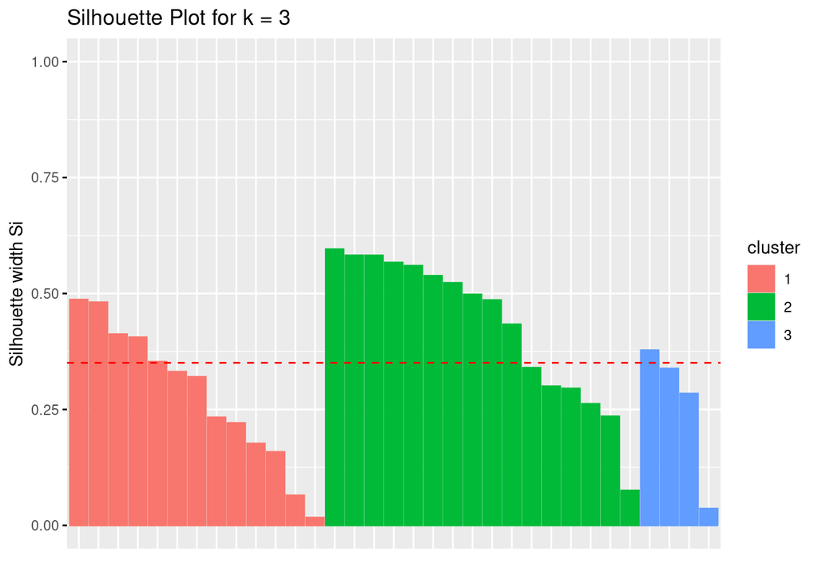

```r
# FViz Silhouette
k <- 3  # Example: testing k = 3
km <- kmeans(scaled_data, centers = k, nstart = 25)
sil <- silhouette(km$cluster, dist(scaled_data))

# Visualize silhouette plot
fviz_silhouette(sil) + labs(title = paste("Silhouette Plot for k =", k))
```

**Silhouette Plot:**

This plot shows individual silhouette widths for each point within the clusters. A silhouette width close to +1 indicates that the sample is far away from the neighboring clusters. A value of 0 indicates that the sample is on or very close to the decision boundary between two neighboring clusters. Negative values indicate that those samples might have been assigned to the wrong cluster.

**Average Silhouette Width Plot:**

This plot presents the average silhouette width for different numbers of clusters. A higher average silhouette width indicates better cluster structure.

**Interpretation:**

The absence of a clear “elbow” in the WSS plot and the moderate silhouette scores together suggest that while there may be some natural grouping in the data, it is not highly distinct. The clusters formed may not be very dense, or there may not be significant separation between them. This could be due to the inherent overlap in user behaviors or the chosen features not capturing clear distinctions between different user profiles.

**Recommendation:**

It looks from this analysis that just 2 clusters are probably the best division, suggesting that there may be one clearish cluster and everything else is lumped together, but none of the numbers are close to what we would expect with clear clusters. Let’s see what we can find with hierarchical clustering, and then attempt PCA followed by a clustering analysis.

**Hierarchical Clustering**

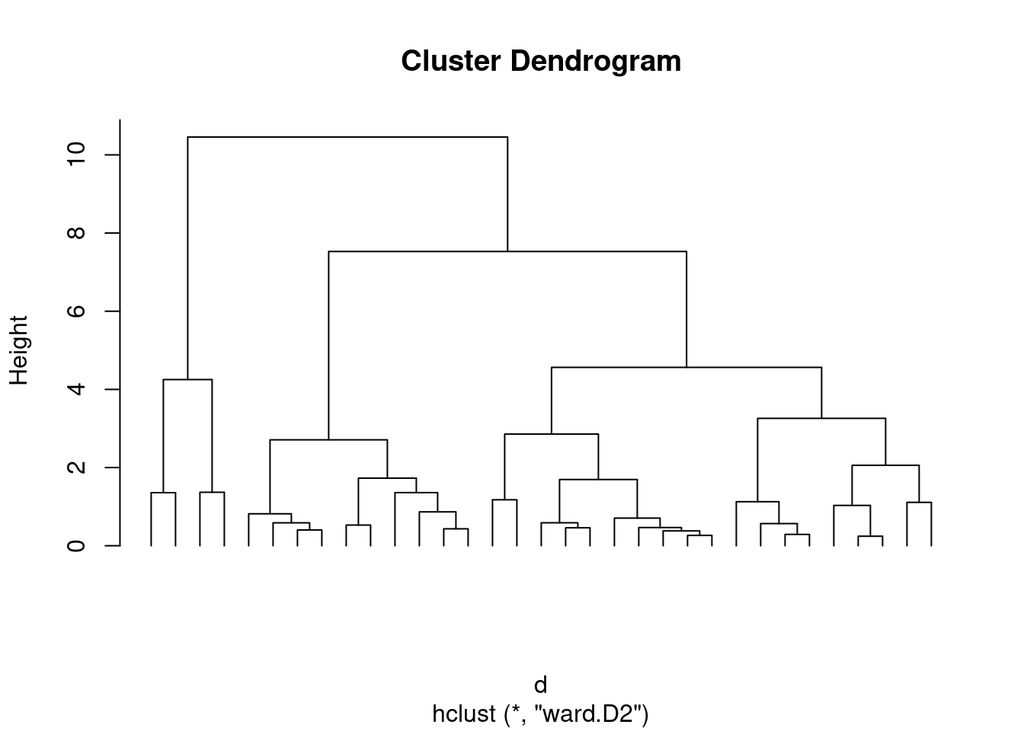

```r
# Using the previously defined 'scaled_data' dataset
library(stats)

# Compute the distance matrix
d <- dist(scaled_data)

# Perform hierarchical clustering using the Ward method
hc <- hclust(d, method = "ward.D2")

# Plot the dendrogram
plot(hc, labels = FALSE, hang = -1)  # 'labels=FALSE' to avoid clutter if there are many data points
```

To me it looks like we get the biggest jumps around height 5, which gives us three clusters. Let’s cut the tree here, divide the users into the different clusters, and examine their statistics.

```r
# Step 1: Cut the dendrogram at height 5 to get cluster assignments
cluster_assignments <- cutree(hc, h = 5)

# Step 2: Join cluster assignments with aggregated user profile data
user_activity_profile$Cluster <- cluster_assignments

# Step 3: Join clusters with original data by mapping each 'Id' to its cluster
cleaned_daily_activity <- cleaned_daily_activity %>%
  left_join(user_activity_profile[c("Id", "Cluster")], by = "Id")

# Step 4: Calculate summary statistics for the original data, grouped by cluster
cluster_summary <- cleaned_daily_activity %>%
  group_by(Cluster) %>%
  summarise(across(c(TotalSteps, TotalDistance, VeryActiveMinutes, Calories, SedentaryMinutes, LightlyActiveMinutes), mean, na.rm = TRUE))
# View the summary statistics for each cluster
print(cluster_summary)
```

```
## # A tibble: 3 × 7
##   Cluster TotalSteps TotalDistance VeryActiveMinutes Calories SedentaryMinutes
##     <int>      <dbl>         <dbl>             <dbl>    <dbl>            <dbl>
## 1       1      9131.          6.44             19.0     2327.             924.
## 2       2      4406.          2.96              4.87    1950.            1056.
## 3       3     12345.          9.77             76.8     3353.             932.
## # ℹ 1 more variable: LightlyActiveMinutes <dbl>
```

```r
# Count unique Ids in each cluster
library(dplyr)

cluster_counts <- cleaned_daily_activity %>%
  group_by(Cluster) %>%
  summarise(UniqueIds = n_distinct(Id))

print(cluster_counts)
```

```
## # A tibble: 3 × 2
##   Cluster UniqueIds
##     <int>     <int>
## 1       1        19
## 2       2        10
## 3       3         4
```

Here, it looks like we do have three quite distinct clusters, particularly in regards to TotalSteps, TotalDistance, VeryActiveMinutes, and Calories.

Cluster 3 looks like our most active group, with 2.8x more avg daily steps than our least active group and 35% more steps than our moderately active group, with a similar amount of difference in TotalDistance. There is less variation, but still significant, in the area of Calories, which is not surprising given the substantial role of base-rate metabolic expenditure. Cluster 3 has ~70% more average daily calorie expenditure than Cluster 2, and 44% more than Cluster 1. The difference is even greater in the VeryActive Minutes category, with Cluster 3 having ~15x more VeryActiveMinutes per day than Cluster 2, and 4x more than Cluster 1. There is less variation seen between the groups in the other variables examined here, with the note that Cluster 2 has significantly more sedentary minutes than the other two groups, and Cluster 1, despite having significantly less VeryActiveMinutes compared to Cluster 3, actually has a significantly higher average daily LightlyActiveMinutes.

**3 User Types** Let’s make some describe our 3 User Types identified by the hierarchical clustering we’ve done and the analysis we’ve performed so far.

*Cluster 3: “The Power Movers”* (4 out of 33 users)- This group is characterized by high levels of activity. They take significantly more steps, burn more calories and have a much higher active engagement, indicating a potentially sporty or fitness-focused lifestyle. These are rare, representing only ~12% of our dataset.

*Cluster 2: “The Casual Navigators”* (10 out of 33 users) - With the most sedentary minutes and by far the least very active minutes, this group might represent everyday individuals who demonstrate a very low level of intense activity, possibly due to work or lifestyle constraints that involve periods of inactivity.

*Cluster 1: “The Consistent Pacers”* (19 out of 33 users- Although they have fewer very active minutes, their higher lightly active minutes suggest they maintain a steady pace throughout the day. This could be indicative of users who engage in regular, moderate-intensity activities, possibly integrating more low-impact exercises or frequent breaks from sedentary behavior into their routine. These are your average people, representing over 57% of the dataset.

Let’s examine these three groups more closely to learn more about them.

```r
library(ggplot2)
library(dplyr)

# First, calculate the average number of TotalSteps for each combination of WeekDay and Cluster
avg_steps_per_weekday <- cleaned_daily_activity %>%
  group_by(WeekDay, Cluster) %>%
  summarise(AvgTotalSteps = mean(TotalSteps, na.rm = TRUE)) %>%
  ungroup() %>%
  mutate(WeekDay = factor(WeekDay, levels = c("Sunday", "Monday", "Tuesday", "Wednesday", "Thursday", "Friday", "Saturday")))
# View the table
print(avg_steps_per_weekday)
```

```
## # A tibble: 21 × 3
##    WeekDay   Cluster AvgTotalSteps
##    <ord>       <int>         <dbl>
##  1 Sunday          1         7877.
##  2 Sunday          2         4748.
##  3 Sunday          3        11999.
##  4 Monday          1         9465.
##  5 Monday          2         4694.
##  6 Monday          3        10566.
##  7 Tuesday         1        10080
##  8 Tuesday         2         4138.
##  9 Tuesday         3        12487.
## 10 Wednesday       1         8744.
## # ℹ 11 more rows
```

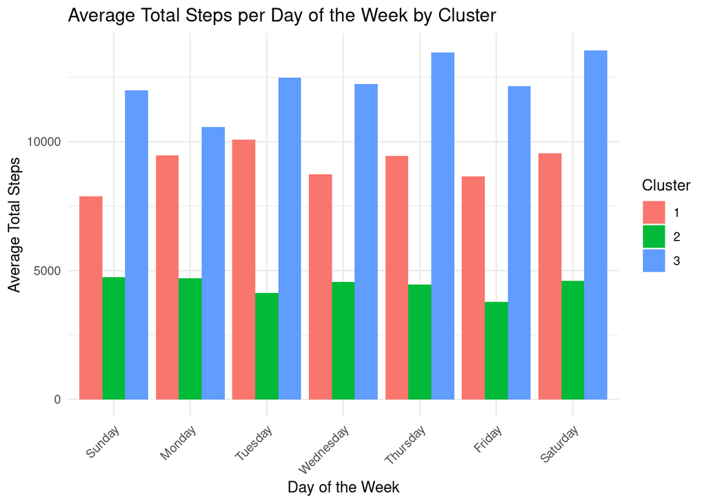

```r
# Now, plot the data
ggplot(avg_steps_per_weekday, aes(x = WeekDay, y = AvgTotalSteps, fill = as.factor(Cluster))) +
  geom_bar(stat = "identity", position = position_dodge()) +
  labs(title = "Average Total Steps per Day of the Week by Cluster",
       x = "Day of the Week",
       y = "Average Total Steps",
       fill = "Cluster") +
  theme_minimal() +
  theme(axis.text.x = element_text(angle = 45, hjust = 1))
```

Cluster 3, the Power Movers, shows significant variation (in Average Total Daily Steps) throughout the week, with Thursday and Saturday being their most active days and Monday being their least active.

Cluster 2, our casual, most sedentary group shows less variation throughout the week, with Sunday and Monday being marginally more active (in terms of number of steps), and Friday being significantly lower. Perhaps this group starts out the week with the most energy, but gradually loses steam over the week and is tired by Friday.

Let’s see if we can apply these clusters to our hourly dataset, and see if there is significant differences between when they have most of their activity.

```r
# Create a mapping of Id to Cluster
cluster_mapping <- cleaned_daily_activity %>%
  select(Id, Cluster) %>%
  distinct()

# Merge this cluster information into hourly_data
hourly_data_clustered <- hourly_data %>%
  left_join(cluster_mapping, by = "Id")
```

```r
# Group by Cluster, Hour, and WeekDay, then summarize
hourly_activity_summary <- hourly_data_clustered %>%
  group_by(Cluster, Hour, WeekDay) %>%
  summarise(
    AvgCalories = mean(Calories, na.rm = TRUE),
    AvgStepTotal = mean(StepTotal, na.rm = TRUE),
    AvgTotalIntensity = mean(TotalIntensity, na.rm = TRUE)
  ) %>%
  ungroup()
# View the summarized data
print(hourly_activity_summary)
```

```
## # A tibble: 504 × 6
##    Cluster  Hour WeekDay   AvgCalories AvgStepTotal AvgTotalIntensity
##      <int> <int> <ord>           <dbl>        <dbl>             <dbl>
##  1       1     0 Sunday           72.4        63.0              3.37
##  2       1     0 Monday           67.2        24.8              1.46
##  3       1     0 Tuesday          66.3        25.8              1.13
##  4       1     0 Wednesday        67.3        29.5              1.58
##  5       1     0 Thursday         66.9        30.4              1.24
##  6       1     0 Friday           69.2        38.9              2.19
##  7       1     0 Saturday         69.7        44.2              2.46
##  8       1     1 Sunday           68.8        35.5              1.71
##  9       1     1 Monday           65.0         3.75             0.319
## 10       1     1 Tuesday          65.4         9.35             0.709
## # ℹ 494 more rows
```

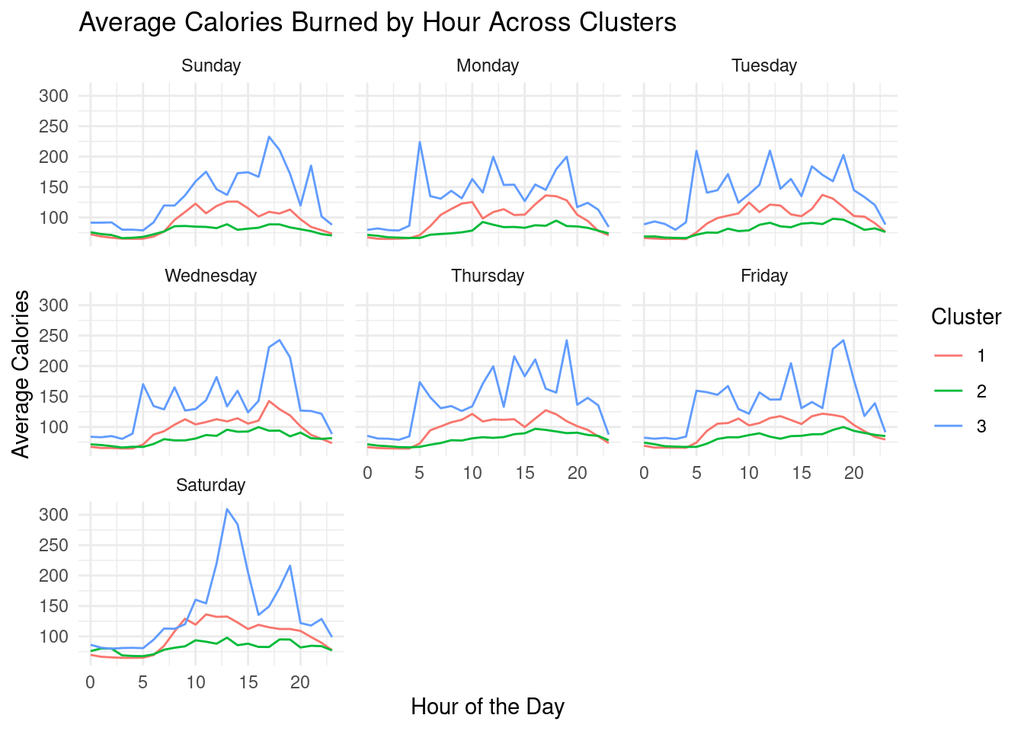

```r
ggplot(hourly_activity_summary, aes(x = Hour, y = AvgCalories, color = as.factor(Cluster), group = Cluster)) +
  geom_line() +
  facet_wrap(~WeekDay) +
  labs(title = "Average Calories Burned by Hour Across Clusters",
       x = "Hour of the Day",
       y = "Average Calories",
       color = "Cluster") +
  theme_minimal()
```

Here we have graphs of the average calories burned, per hour of the day, per day of the week, per cluster.

Overall Trends:

There are noticeable peaks and troughs in calorie burn for all clusters throughout the day, which likely correspond to times of increased and decreased physical activity.

Cluster 1 (Red):

Cluster 3 (Blue):

Cluster 2 (Green):

Let’s examine these a little more closely:

**Cluster 1: Consistent Pacers**

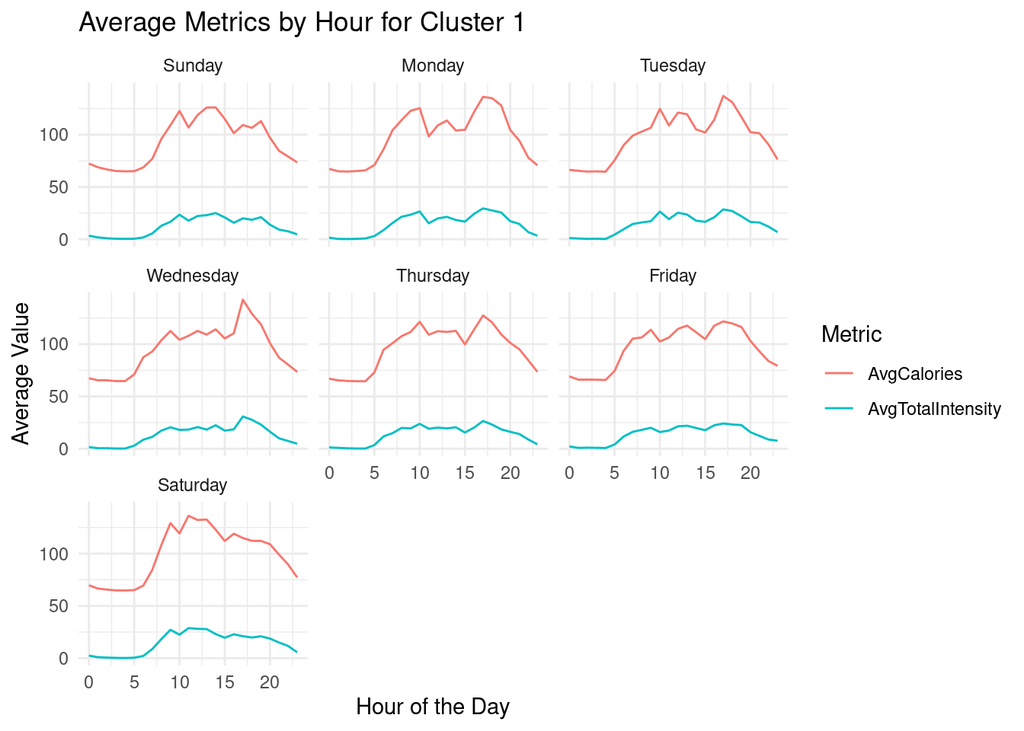

```r
library(tidyr)
library(ggplot2)
library(dplyr)

# Group by Cluster, Hour, and WeekDay, then summarize
hourly_activity_summary <- hourly_data_clustered %>%
  group_by(Cluster, Hour, WeekDay) %>%
  summarise(
    AvgCalories = mean(Calories, na.rm = TRUE),
    AvgStepTotal = mean(StepTotal, na.rm = TRUE),
    AvgTotalIntensity = mean(TotalIntensity, na.rm = TRUE)
  ) %>%
  ungroup()
# Filter the summarized data for Cluster 1
cluster_1_activity_summary <- hourly_activity_summary %>%
  filter(Cluster == 1)

# Reshape the data to long format
cluster_1_activity_long <- cluster_1_activity_summary %>%
  pivot_longer(
    cols = c("AvgCalories", "AvgTotalIntensity"),
    names_to = "Variable",
    values_to = "Value"
  )

# Plot all three variables on the same graph
ggplot(cluster_1_activity_long, aes(x = Hour, y = Value, color = Variable, group = Variable)) +
  geom_line() +
  facet_wrap(~WeekDay) +
  labs(title = "Average Metrics by Hour for Cluster 1",
       x = "Hour of the Day",
       y = "Average Value",
       color = "Metric") +
  theme_minimal()
```

The Consistent Pacers (are largest and moderately active group), show the above patterns of activity throughout the day and week. Here are some observations:

Morning Hours:

For both AvgCalories and AvgTotalIntensity, there is a gradual increase starting from the early hours, around 5-6 AM, which suggests some individuals begin their activities early in the day.

Midday Peaks:

Troughs:

The lowest points for both metrics occur in the very early morning, roughly from midnight to 5 AM, which is expected as this is typically a resting period for most people. Evening Activity:

Weekend Variations:

On Sundays, the curve for AvgCalories is flatter with a less pronounced peak, suggesting less activity. This could be interpreted as a rest day for many in the cluster.

**Cluster 2: The Low and Slows**

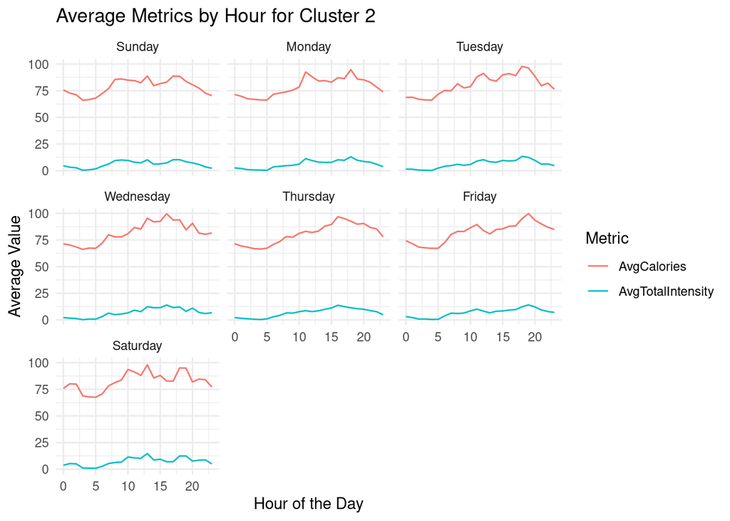

```r
library(tidyr)
library(ggplot2)
library(dplyr)

# Group by Cluster, Hour, and WeekDay, then summarize
hourly_activity_summary <- hourly_data_clustered %>%
  group_by(Cluster, Hour, WeekDay) %>%
  summarise(
    AvgCalories = mean(Calories, na.rm = TRUE),
    AvgStepTotal = mean(StepTotal, na.rm = TRUE),
    AvgTotalIntensity = mean(TotalIntensity, na.rm = TRUE)
  ) %>%
  ungroup()
# Filter the summarized data for Cluster 1
cluster_2_activity_summary <- hourly_activity_summary %>%
  filter(Cluster == 2)

# Reshape the data to long format
cluster_2_activity_long <- cluster_2_activity_summary %>%
  pivot_longer(
    cols = c("AvgCalories", "AvgTotalIntensity"),
    names_to = "Variable",
    values_to = "Value"
  )

# Plot all three variables on the same graph
ggplot(cluster_2_activity_long, aes(x = Hour, y = Value, color = Variable, group = Variable)) +
  geom_line() +
  facet_wrap(~WeekDay) +
  labs(title = "Average Metrics by Hour for Cluster 2",
       x = "Hour of the Day",
       y = "Average Value",
       color = "Metric") +
  theme_minimal()
```

Here we see hourly and daily average calorie expenditures and total intensity for Cluster 2: The Casual Navigators or the Low and Slows, our least active group.

Morning Activity:

Following the peak, there is a gradual decrease in AvgCalories, but the level remains elevated compared to the morning hours, indicating sustained activity throughout the afternoon. Evening Activity:

There is a less noticeable decline in the evening for AvgCalories, suggesting that Cluster 2 may have a more extended period of activity that lasts into the evening, although not as intense as the midday peak. Intensity Trends:

The AvgTotalIntensity for Cluster 2 is quite flat throughout the day, with only slight fluctuations. This suggests that the intensity of their activities does not vary as much as the calorie expenditure does. Late Evening:

Activity for both AvgCalories and AvgTotalIntensity starts to taper off after 8 PM, heading towards the minimal values by midnight. Weekend Patterns:

Comparative Weekday vs. Weekend:

There are noticeable differences between weekday and weekend activity levels. The weekend days show a more leveled pattern with less distinction between peak and non-peak hours, which might reflect a more relaxed pace or varied activities.

These observations suggest that individuals in Cluster 2 have a distinct pattern of activity with a later peak in calorie burn and a relatively consistent intensity of activity throughout the day. The weekends show a tendency for activities to start earlier and spread more evenly across the day compared to weekdays.

**Cluster 3: The Power Movers**

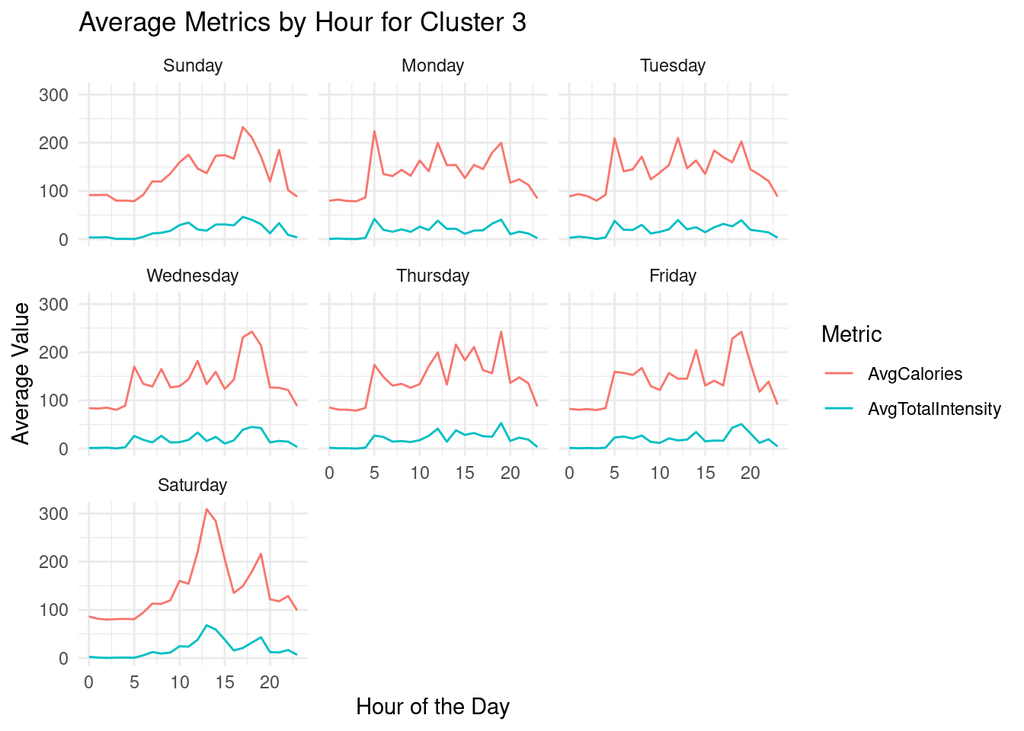

```r
library(tidyr)
library(ggplot2)
library(dplyr)

# Group by Cluster, Hour, and WeekDay, then summarize
hourly_activity_summary <- hourly_data_clustered %>%
  group_by(Cluster, Hour, WeekDay) %>%
  summarise(
    AvgCalories = mean(Calories, na.rm = TRUE),
    AvgStepTotal = mean(StepTotal, na.rm = TRUE),
    AvgTotalIntensity = mean(TotalIntensity, na.rm = TRUE)
  ) %>%
  ungroup()
# Filter the summarized data for Cluster 1
cluster_3_activity_summary <- hourly_activity_summary %>%
  filter(Cluster == 3)

# Reshape the data to long format
cluster_3_activity_long <- cluster_3_activity_summary %>%
  pivot_longer(
    cols = c("AvgCalories", "AvgTotalIntensity"),
    names_to = "Variable",
    values_to = "Value"
  )

# Plot all three variables on the same graph
ggplot(cluster_3_activity_long, aes(x = Hour, y = Value, color = Variable, group = Variable)) +
  geom_line() +
  facet_wrap(~WeekDay) +
  labs(title = "Average Metrics by Hour for Cluster 3",
       x = "Hour of the Day",
       y = "Average Value",
       color = "Metric") +
  theme_minimal()
```

Here we have the hourly and daily graphs of AvgCalories and AvgTotalIntensity for Cluster 3: The Power Movers. Keep in mind, this only represents 4 users out of the 33 in our sample.

During the weekdays, we see a significant spike in activity starting around 5am (with the most significant spikes being on Monday and Tuesday, which might represent some pre-work exercise in the earlier days of the week), with additional peaks around midday (noonish), and usually a spike in the evening as well (roughly 6-7pm), with usually a significant dropoff around 8pm. Interestingly, Mondays and Tuesdays seem to be dominated by the morning activity, with a lower peak in the evening, whereas Wednesday, Thursday, Friday show less morning activity but significantly more in the evenings after work, with the Wednesday evening workout being especially prolonged.

Saturday shows a much slower and more gradual start in the morning, but a significant activity peak around 1pm, then a trough around 4pm and a lesser peak around 7pm. Sunday looks like a rest day, with a similar pattern to Saturday except with no activity peak around midday, instead showing the day’s peak around 5pm.

This concludes are general observations about our different clusters. I’ll recap their traits and associated recommendations at the end.

Now, let’s move on the examining our last dataset, Activity Plus Sleep.

### Activity Plus Sleep

Recall that this dataset is a merge of the original daily_activity dataset along with the sleep dataset for the ’Id’s that were common between them. We have a reduced number of users in this sample, with only 24 users instead of our 33.

```r
# Find the number of unique Ids in the 'Id' column using base R
number_of_unique_ids <- length(unique(activity_plus_sleep$Id))

# Print the result
print(number_of_unique_ids)
```

```
## [1] 24
```

```r
# Look at dataset head
head(activity_plus_sleep)
```

```
##           Id       Date TotalSteps TotalDistance TrackerDistance
## 1 1503960366 2016-04-12      13162          8.50            8.50
## 2 1503960366 2016-04-13      10735          6.97            6.97
## 3 1503960366 2016-04-15       9762          6.28            6.28
## 4 1503960366 2016-04-16      12669          8.16            8.16
## 5 1503960366 2016-04-17       9705          6.48            6.48
## 6 1503960366 2016-04-19      15506          9.88            9.88
##   VeryActiveDistance ModeratelyActiveDistance LightActiveDistance
## 1               1.88                     0.55                6.06
## 2               1.57                     0.69                4.71
## 3               2.14                     1.26                2.83
## 4               2.71                     0.41                5.04
## 5               3.19                     0.78                2.51
## 6               3.53                     1.32                5.03
##   VeryActiveMinutes FairlyActiveMinutes LightlyActiveMinutes SedentaryMinutes
## 1                25                  13                  328              728
## 2                21                  19                  217              776
## 3                29                  34                  209              726
## 4                36                  10                  221              773
## 5                38                  20                  164              539
## 6                50                  31                  264              775
##   Calories TotalMinutesAsleep TotalTimeInBed   WeekDay
## 1     1985                327            346   Tuesday
## 2     1797                384            407 Wednesday
## 3     1745                412            442    Friday
## 4     1863                340            367  Saturday
## 5     1728                700            712    Sunday
## 6     2035                304            320   Tuesday
```

Here we still have TrackerDistance, which in a previous dataset we determined was so correlated with TotalDistance that it was redundant Let’s first look at how correlated TotalMinutesAsleep and TotalTimeInBed are to see if they are distinct or if we can elminate one.

```r
#Examine Correlations
correlation_matrix <- cor(activity_plus_sleep[,c('TotalMinutesAsleep', 'TotalTimeInBed')], use = "complete.obs")

# Display the correlation matrix
print(correlation_matrix)
```

```
##                    TotalMinutesAsleep TotalTimeInBed
## TotalMinutesAsleep          1.0000000      0.9304224
## TotalTimeInBed              0.9304224      1.0000000
```

Those are so closely correlated that they are functionally tracking the same thing, so let’s drop TotalTimeInBed and TrackerDistance.

```r
# Drop the columns from the dataset
activity_plus_sleep <- activity_plus_sleep %>%
  select(-TotalTimeInBed, -TrackerDistance)
```

Now let’s look to see what correlations we have between the rest of our variables:

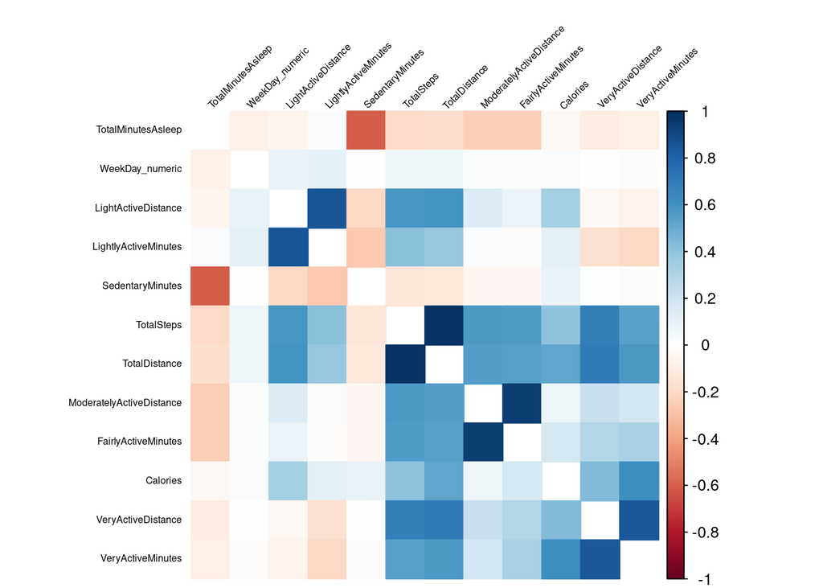

```r
# Load the necessary libraries
library(corrplot)
library(dplyr)

# Convert 'WeekDay' to an ordered factor
activity_plus_sleep$WeekDay <- factor(activity_plus_sleep$WeekDay,
                                      levels = c("Sunday", "Monday", "Tuesday", "Wednesday", "Thursday", "Friday", "Saturday"),
                                      ordered = TRUE)

# Convert 'WeekDay' to a numeric scale based on its order
activity_plus_sleep$WeekDay_numeric <- as.numeric(activity_plus_sleep$WeekDay)
# Note, interpret correlations with caution as it's an ordinal variable

# Select only numeric columns and exclude 'Id'
numeric_data <- activity_plus_sleep %>%
  select_if(~is.numeric(.)) %>%
  select(-Id)

# Calculate the correlation matrix for numeric columns
cor_matrix <- cor(numeric_data, use = "pairwise.complete.obs")

# Create the correlation heatmap with annotations
corrplot(cor_matrix, method = "color",
         tl.col = "black", tl.srt = 45, tl.cex = 0.5, # Adjust text color, angle, and size for variable names
         number.cex = 0.5, # Adjust text size for correlation coefficients
         diag = FALSE, # Remove the diagonal
         order = "hclust", # Order variables based on hierarchical clustering
         mar = c(0,0,1,1) # Increase margins (bottom, left, top, right)
)
```

Most of the strongest correlations that we see are what we would expect, with correlations, e.g. between TotalSteps with TotalDistance and ModeratelyActiveDistance with FairlyActiveMinutes. Interestingly, we see a strong negative correlation between SedentaryMinutes and TotalMinutesAsleep. Let’s reduce the number of variables we are looking at in order to reduce collinearity and get a better picture.

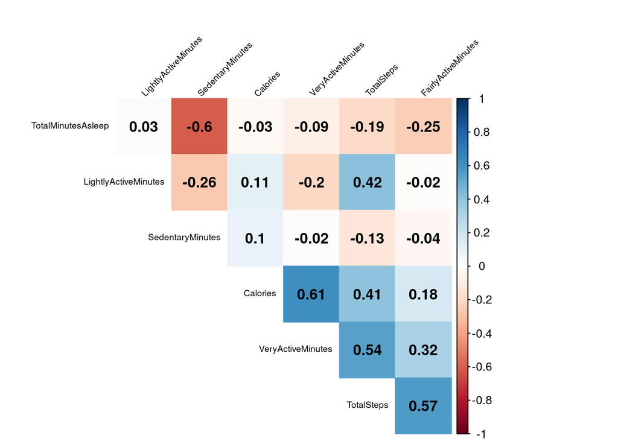

```r
# Load the necessary library
library(corrplot)

# Select only the variables of interest
selected_data <- activity_plus_sleep[, c('TotalMinutesAsleep', 'LightlyActiveMinutes',
                                         'SedentaryMinutes', 'TotalSteps',
                                         'FairlyActiveMinutes', 'Calories',
                                         'VeryActiveMinutes')]

# Calculate the correlation matrix for the selected variables
cor_matrix <- cor(selected_data, use = "pairwise.complete.obs")

# Create the correlation heatmap with annotations for the selected variables
corrplot(cor_matrix, method = "color",
         type = "upper",
         tl.col = "black", tl.srt = 45, tl.cex = 0.6,
         addCoef.col = "black",
         diag = FALSE,
         order = "hclust",
         mar = c(0,0,2,2))
```

We have a number of moderate to strong correlations between variables here. The strongest are between Calories and VeryActiveMinutes (which suggests that being more active does lead to more calories burned) and TotalMinutesAsleep and Sedentary minutes, which show a strong negative correlation, suggesting that the more sleep you get the fewer sedentary minutes you have, and vice versa. Almost as strong are TotalSteps with FairlyActiveMinutes (which is our moderately active status), TotalSteps with VeryActiveMinutes, and TotalSteps with LightlyActiveMinutes. On the low side of moderate, Calories burned are somewhat correlated with TotalSteps. Interestingly, Calories burned has almost no correlation with SedentaryMinutes, suggesting that more sedentary time doesn’t lead necessarily to fewer calories burned (which might be because sleep, presumably, counts as sedentary time).

Let’s look at some other ways of examining our sleep data; our overall statistics, variations by person, and variations by weekday:

```r
# 1. Examine Overall Patterns
summary_stats <- summary(activity_plus_sleep$TotalMinutesAsleep)

# View the quick summary statistics
print(summary_stats)
```

```
##    Min. 1st Qu.  Median    Mean 3rd Qu.    Max.
##    58.0   361.0   432.5   419.2   490.0   796.0
```

```r
# 2. Examine Patterns by Person with additional summary statistics
patterns_by_person <- activity_plus_sleep %>%
  group_by(Id) %>%
  summarise(
    AverageMinutesAsleep = mean(TotalMinutesAsleep, na.rm = TRUE),
    SDMinutesAsleep = sd(TotalMinutesAsleep, na.rm = TRUE),
    MedianMinutesAsleep = median(TotalMinutesAsleep, na.rm = TRUE),
    MinMinutesAsleep = min(TotalMinutesAsleep, na.rm = TRUE),
    MaxMinutesAsleep = max(TotalMinutesAsleep, na.rm = TRUE),
    NA_Count = sum(is.na(TotalMinutesAsleep))
  )
print(patterns_by_person)
```

```
## # A tibble: 24 × 7
##            Id AverageMinutesAsleep SDMinutesAsleep MedianMinutesAsleep
##         <dbl>                <dbl>           <dbl>               <dbl>
##  1 1503960366                 360.           100.                 340
##  2 1644430081                 294            335.                 130.
##  3 1844505072                 652             66.4                644
##  4 1927972279                 417            219.                 398
##  5 2026352035                 506.            42.3                516.
##  6 2320127002                  61             NA                   61
##  7 2347167796                 447.            43.0                445
##  8 3977333714                 294.            63.9                292.
##  9 4020332650                 349.           141.                 374.
## 10 4319703577                 477.           114.                 494.
## # ℹ 14 more rows
## # ℹ 3 more variables: MinMinutesAsleep <int>, MaxMinutesAsleep <int>,
## #   NA_Count <int>
```

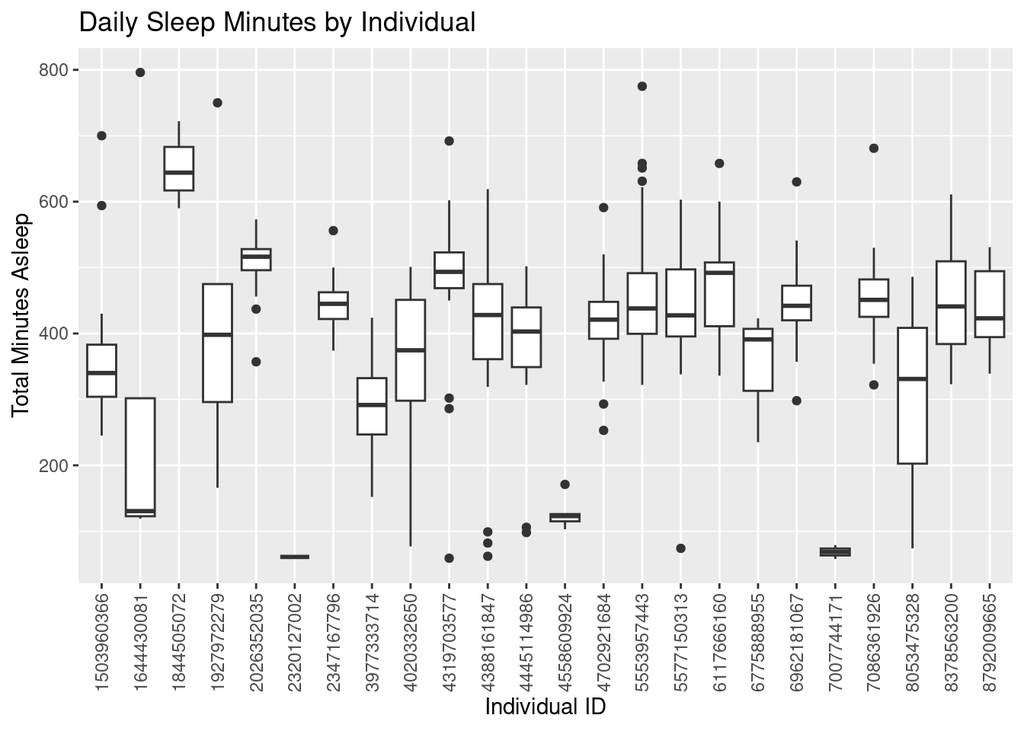

```r
# Create boxplots for each person's daily sleep minutes
ggplot(activity_plus_sleep, aes(x = as.factor(Id), y = TotalMinutesAsleep)) +
  geom_boxplot() +
  labs(title = "Daily Sleep Minutes by Individual", x = "Individual ID", y = "Total Minutes Asleep") +
  theme(axis.text.x = element_text(angle = 90, vjust = 0.5, hjust=1))  # Rotate x-axis text if necessary
```

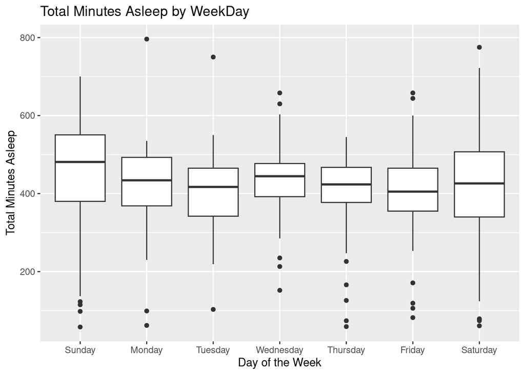

```r
# 3. Examine Variations Over Time by WeekDay with boxplots
ggplot(activity_plus_sleep, aes(x = WeekDay, y = TotalMinutesAsleep)) +
  geom_boxplot() +
  labs(title = "Total Minutes Asleep by WeekDay", x = "Day of the Week", y = "Total Minutes Asleep")
```

**Overall Sleep Statistics** Based on these data (which, recall, is based on 24 people gathered over 1 month using a Fitness Tracker), there is a min of 58 minutes (which seems possible, but unlikely, and may be the result of a tracker error or inconsistent use during sleep), and a max of about 800 minutes (which represents over 13 hours asleep in a day, which is also possible but perhaps not likely, and may also be the result of a tracker or user error). We see a mean and median that are quite close (suggesting not too many outliers) centered around ~420 minutes, or 7 hours of sleep, which seems normal, and we have an IQR almost exactly spreading from 6 hours to 8 hours, which seems very normal and suggests fairly accurate data.

*Median Sleep Duration:* The median total minutes asleep, indicated by the line within each box, does not vary greatly across the weekdays. It appears relatively consistent, suggesting that individuals tend to have a stable sleep duration throughout the week.

*Interquartile Range (IQR):* The IQR, represented by the height of each box, is somewhat consistent across all days, with Wednesday showing a slightly tighter IQR, implying less variability in sleep duration on that day among the participants.

*Range of Sleep Durations:* The range, indicated by the whiskers, shows that there is a wide variation in sleep duration among individuals on each day. However, the ranges are similar across the weekdays, with no day showing an extreme difference in sleep variation.

*Consistency:* Despite individual variations, the overall sleep patterns seem relatively consistent across the week, as seen by the similarity in the spread and central tendency (median) of the boxplots.

**Variations by User** We have no nulls, but we do have two user IDs (2320127002 and 7007744171) that show a maximum sleep over the time period of just over an hour, which seems unlikely over a month without either User or FitBit error. A third (4558609924), has sleep patterns that are almost as unlikely and very out of norm with the rest. I’ll drop those three and then examine user variation more fully.

Based on the boxplot image, which displays the distribution of daily sleep minutes for individuals over a one-month period, here are some significant observations:

*Variability Among Individuals:*

There is considerable variability in sleep patterns among individuals. Some have a wide range of sleep minutes (indicated by the height of the box and whiskers), while others have a more consistent sleep duration.

*Potential Outliers:*

There are a number of potential outliers, which are represented by individual points outside the “whiskers” of the boxplots. These points could represent unusually short or long sleep durations compared to the individual’s typical pattern, or perhaps just errors with how the FitBit recorded sleep or how the users wore them.

*Median Sleep Duration:*

The line inside the box (median) varies among individuals, indicating that the central tendency of sleep duration is different across the sample. Some individuals tend to sleep more, and others less, based on the median line within each box.

*Interquartile Range (IQR):*

The size of the boxes, which represent the interquartile range (the middle 50% of the data), varies between individuals. A larger box indicates more variability in sleep duration from night to night, whereas a smaller box indicates more consistency.

*Minimum and Maximum Sleep Durations:*

The “whiskers” of the boxplots show the range of typical sleep duration (excluding outliers), and there is a wide range among individuals. Some have a broader range of sleep minutes, indicating inconsistency in sleep duration.

*Sleep Hygiene:*

Some individuals show a very tight IQR with a consistent median, which could be indicative of good sleep hygiene and regular sleep habits. Conversely, individuals with a wide IQR might have irregular sleep patterns, which could be a point of concern or investigation.

Let’s filter out the outlier users and look at a linear regression examining a few variables and how sleep influences them.

```r
# Filter out the outlier user IDs
filtered_data <- activity_plus_sleep %>%
  filter(!(Id %in% c(2320127002, 7007744171, 4558609924)))

# Load the dplyr package
library(dplyr)

# Assuming you have already filtered out the unwanted user IDs

# Model TotalSteps as a function of TotalMinutesAsleep
steps_model <- lm(TotalSteps ~ TotalMinutesAsleep, data = filtered_data)
summary(steps_model)
```

```
##
## Call:
## lm(formula = TotalSteps ~ TotalMinutesAsleep, data = filtered_data)
##
## Residuals:
##     Min      1Q  Median      3Q     Max
## -9593.9 -3078.4   429.6  2775.6 14627.1
##
## Coefficients:
##                     Estimate Std. Error t value Pr(>|t|)
## (Intercept)        12218.786    804.028  15.197  < 2e-16 ***
## TotalMinutesAsleep    -8.635      1.829  -4.722 3.24e-06 ***
## ---
## Signif. codes:  0 '***' 0.001 '**' 0.01 '*' 0.05 '.' 0.1 ' ' 1
##
## Residual standard error: 4064 on 400 degrees of freedom
## Multiple R-squared:  0.05279,    Adjusted R-squared:  0.05043
## F-statistic: 22.29 on 1 and 400 DF,  p-value: 3.241e-06
```

```r
# Model Calories as a function of TotalMinutesAsleep
calories_model <- lm(Calories ~ TotalMinutesAsleep, data = filtered_data)
summary(calories_model)
```

```
##
## Call:
## lm(formula = Calories ~ TotalMinutesAsleep, data = filtered_data)
##
## Residuals:
##     Min      1Q  Median      3Q     Max
## -2183.0  -541.2  -182.2   521.0  2536.2
##
## Coefficients:
##                     Estimate Std. Error t value Pr(>|t|)
## (Intercept)        2551.6444   151.0829  16.889   <2e-16 ***
## TotalMinutesAsleep   -0.3698     0.3437  -1.076    0.283
## ---
## Signif. codes:  0 '***' 0.001 '**' 0.01 '*' 0.05 '.' 0.1 ' ' 1
##
## Residual standard error: 763.7 on 400 degrees of freedom
## Multiple R-squared:  0.002886,   Adjusted R-squared:  0.0003933
## F-statistic: 1.158 on 1 and 400 DF,  p-value: 0.2826
```

```r
# Model SedentaryMinutes as a function of TotalMinutesAsleep
sedentary_model <- lm(SedentaryMinutes ~ TotalMinutesAsleep, data = filtered_data)
summary(sedentary_model)
```

```
##
## Call:
## lm(formula = SedentaryMinutes ~ TotalMinutesAsleep, data = filtered_data)
##
## Residuals:
##     Min      1Q  Median      3Q     Max
## -802.78  -54.23    6.26   66.92  357.21
##
## Coefficients:
##                      Estimate Std. Error t value Pr(>|t|)
## (Intercept)        1042.10114   26.30027   39.62   <2e-16 ***
## TotalMinutesAsleep   -0.79247    0.05982  -13.25   <2e-16 ***
## ---
## Signif. codes:  0 '***' 0.001 '**' 0.01 '*' 0.05 '.' 0.1 ' ' 1
##
## Residual standard error: 132.9 on 400 degrees of freedom
## Multiple R-squared:  0.3049, Adjusted R-squared:  0.3032
## F-statistic: 175.5 on 1 and 400 DF,  p-value: < 2.2e-16
```

```r
# Model VeryActiveMinutes as a function of TotalMinutesAsleep
very_active_model <- lm(VeryActiveMinutes ~ TotalMinutesAsleep, data = filtered_data)
summary(very_active_model)
```

```
##
## Call:
## lm(formula = VeryActiveMinutes ~ TotalMinutesAsleep, data = filtered_data)
##
## Residuals:
##    Min     1Q Median     3Q    Max
## -39.38 -22.88 -15.41  11.52 189.22
##
## Coefficients:
##                    Estimate Std. Error t value Pr(>|t|)
## (Intercept)        41.64356    7.16287   5.814 1.25e-08 ***
## TotalMinutesAsleep -0.03842    0.01629  -2.358   0.0188 *
## ---
## Signif. codes:  0 '***' 0.001 '**' 0.01 '*' 0.05 '.' 0.1 ' ' 1
##
## Residual standard error: 36.21 on 400 degrees of freedom
## Multiple R-squared:  0.01371,    Adjusted R-squared:  0.01125
## F-statistic: 5.561 on 1 and 400 DF,  p-value: 0.01885
```

**Findings**

The results from the four linear regression models suggest the following overall findings and conclusions:

*TotalSteps and Sleep:*

There is a significant negative relationship between ‘TotalMinutesAsleep’ and ‘TotalSteps’. This means that, on average, for each additional minute asleep, the number of steps taken decreases. The relationship is statistically significant but has a relatively small effect size (Multiple R-squared of 0.05279), indicating that sleep minutes explain about 5% of the variability in the total steps taken.

*Calories and Sleep:*

The relationship between ‘TotalMinutesAsleep’ and ‘Calories’ is not statistically significant. This suggests that, within this dataset, the amount of sleep does not have a clear association with the number of calories burned.

*SedentaryMinutes and Sleep:*

A significant negative relationship exists between ‘TotalMinutesAsleep’ and ‘SedentaryMinutes’. This indicates that more time spent sleeping is associated with fewer sedentary minutes, with a somewhat larger effect size (Multiple R-squared of 0.3049). Sleep minutes explain approximately 30% of the variability in sedentary minutes, which is a substantial proportion.

*VeryActiveMinutes and Sleep:*

There is a significant negative relationship between ‘TotalMinutesAsleep’ and ‘VeryActiveMinutes’, but the effect size is quite small (Multiple R-squared of 0.01371). This indicates that more sleep is associated with fewer very active minutes, but the effect is not strong.

This is in keeping with my previous analysis of correlations.

# Conclusions and Recommendations

**Summary of Findings:**

**Recommendations:**

- Tailored Engagement Strategies: Develop targeted engagement strategies for each user cluster. Encourage Power Movers with challenges and rewards for maintaining their high activity levels. Offer Casual Navigators personalized prompts to integrate more activity into their routine, and support Consistent Pacers with tools to track and enhance their steady activity patterns.
- Temporal Activity Features: Introduce features that capitalize on the identified temporal activity patterns, such as morning motivation alerts for weekdays and midday activity challenges on weekends, aligning with users’ preferred activity times.
- Sleep and Activity Integration: Leverage the strong correlation between sleep and sedentary behavior by introducing sleep tracking and analysis features that encourage users to adopt healthier sleep patterns as a strategy to reduce sedentary time and increase overall activity.
- Data-Driven Personalization: Utilize the insights from the regression analysis to personalize recommendations, emphasizing the benefits of balanced sleep for activity levels. For example, suggest optimal times for activity based on individual sleep patterns and historical activity peaks.
- Educational Content: Create content that educates users on the benefits of synchronizing sleep and activity patterns, offering tips for optimizing sleep to enhance daytime energy levels and activity.

By implementing these recommendations, Bellabeat can offer more personalized, data-driven insights and interventions, fostering a more engaged and active user community, ultimately driving better health and wellness outcomes.